# property_recommender_system

### 3.6 Autoencoder Improvement Experiments

The following experiments are designed to explore potential improvements to the autoencoder model previously developed. The baseline model has an input dimension of 18, an embedding dimension of 10, and utilizes 'relu' activation for hidden layers and the embedding layer, with 'linear' for the output reconstruction layer. It employs Adam optimizer, MSE loss, Batch Normalization, and Dropout(0.3).

**Load and Prepare Data**

```python
import os
import pandas as pd
import numpy as np

sample_size = 300000
sampled_data_filename = 'realtor_data_sample_300k.csv'

if os.path.exists(sampled_data_filename):
    print(f"Loaded sampled data: {sampled_data_filename}")
    df_sample = pd.read_csv(sampled_data_filename)
else:
    print(f"Sampling df_clean (size: {len(df_clean) if 'df_clean' in locals() else 'not defined'}) to {sample_size} rows.")
    df_sample = df_clean.sample(n=sample_size, random_state=42)
    df_sample.to_csv(sampled_data_filename, index=False)
    print(f"Saved sampled data to: {sampled_data_filename}")

print(f"Working with {len(df_sample)} rows.")

selected_features = [
    'price', 'bed', 'bath', 'acre_lot', 'house_size', 'has_prev_sale',
    'brokered_by_encoded', 'status_for_sale', 'status_ready_to_build',
    'status_sold', 'city_encoded', 'state_encoded', 'zip_code_encoded',
    'price_range_<100k', 'price_range_100k-300k', 'price_range_300k-600k',
    'price_range_600k-1M', 'price_range_1M+'
]

item_features_matrix = df_sample[selected_features].values.astype(np.float64)
```

#### 3.6.1 Experiment 1: Varying the Embedding Dimension

The embedding dimension (bottleneck size) is critical. The current dimension is 10.

##### Hypothesis (Increasing):

A slightly larger embedding dimension (e.g., 16) might allow the model to capture more complex, non-linear relationships between property features, leading to richer embeddings. This could reduce information loss at the bottleneck.

This experiment focuses on increasing the dimension.

```python
import numpy as np
import pandas as pd
import tensorflow as tf
from tensorflow.keras.layers import Input, Dense, Dropout, BatchNormalization
from tensorflow.keras.models import Model
from tensorflow.keras.callbacks import EarlyStopping, ReduceLROnPlateau, ModelCheckpoint
from sklearn.model_selection import train_test_split
import matplotlib.pyplot as plt

print(f"TensorFlow Version: {tf.__version__}")

# Split data
X_train, X_val = train_test_split(item_features_matrix, test_size=0.15, random_state=42)
print(f"Shape of training data (X_train): {X_train.shape}")
print(f"Shape of validation data (X_val): {X_val.shape}")

# --- 2. Define Autoencoder Architecture ---
INPUT_DIM = X_train.shape[1]
# MODIFICATION FOR EXPERIMENT 1: Change EMBEDDING_DIM
EMBEDDING_DIM_EXP1 = 16 # Original was 10

# --- Encoder ---
input_layer_exp1 = Input(shape=(INPUT_DIM,), name='encoder_input_exp1')
enc_exp1 = Dense(256, activation='relu')(input_layer_exp1)
enc_exp1 = BatchNormalization()(enc_exp1)
enc_exp1 = Dropout(0.3)(enc_exp1)
enc_exp1 = Dense(128, activation='relu')(enc_exp1)
enc_exp1 = BatchNormalization()(enc_exp1)
enc_exp1 = Dropout(0.3)(enc_exp1)
encoded_output_exp1 = Dense(EMBEDDING_DIM_EXP1, activation='relu', name='embedding_layer_exp1')(enc_exp1)

# --- Decoder ---
dec_exp1 = Dense(128, activation='relu')(encoded_output_exp1)
dec_exp1 = BatchNormalization()(dec_exp1)
dec_exp1 = Dropout(0.3)(dec_exp1)
dec_exp1 = Dense(256, activation='relu')(dec_exp1)
dec_exp1 = BatchNormalization()(dec_exp1)
dec_exp1 = Dropout(0.3)(dec_exp1)
decoded_output_exp1 = Dense(INPUT_DIM, activation='linear', name='decoder_output_exp1')(dec_exp1)

# --- Define Models ---
autoencoder_exp1 = Model(inputs=input_layer_exp1, outputs=decoded_output_exp1, name='autoencoder_exp1')
encoder_model_exp1 = Model(inputs=input_layer_exp1, outputs=encoded_output_exp1, name='encoder_exp1')

autoencoder_exp1.summary()

# --- 3. Compile the Model ---
LEARNING_RATE = 0.001
OPTIMIZER_EXP1 = tf.keras.optimizers.Adam(learning_rate=LEARNING_RATE)
LOSS = 'mean_squared_error'
autoencoder_exp1.compile(optimizer=OPTIMIZER_EXP1, loss=LOSS, metrics=['mean_absolute_error'])

# --- 4. Define Callbacks ---
early_stopping_exp1 = EarlyStopping(monitor='val_loss', patience=15, restore_best_weights=True, verbose=1)
reduce_lr_exp1 = ReduceLROnPlateau(monitor='val_loss', factor=0.2, patience=7, min_lr=1e-6, verbose=1)
model_checkpoint_exp1 = ModelCheckpoint(filepath='best_autoencoder_model_exp1.keras',
                                     monitor='val_loss', save_best_only=True, verbose=1)
CALLBACKS_EXP1 = [early_stopping_exp1, reduce_lr_exp1, model_checkpoint_exp1]

# --- 5. Train the Autoencoder ---
EPOCHS = 200
BATCH_SIZE = 256
print(f"Starting Autoencoder training for Experiment 1 (Embedding Dim: {EMBEDDING_DIM_EXP1})...")
history_exp1 = autoencoder_exp1.fit(
    X_train, X_train,
    epochs=EPOCHS,
    batch_size=BATCH_SIZE,
    shuffle=True,
    validation_data=(X_val, X_val),
    callbacks=CALLBACKS_EXP1,
    verbose=1
)
print("\nAutoencoder training for Experiment 1 finished.")

# --- 6. Evaluate (Example) ---
val_loss_exp1, val_mae_exp1 = autoencoder_exp1.evaluate(X_val, X_val, verbose=0)
print(f"Experiment 1 - Final Validation MSE: {val_loss_exp1:.4f}, MAE: {val_mae_exp1:.4f}")

# --- 7. Extract Embeddings (Example) ---
all_property_embeddings_exp1 = encoder_model_exp1.predict(item_features_matrix, batch_size=BATCH_SIZE)
np.save('item_embeddings_exp1.npy', all_property_embeddings_exp1)
encoder_model_exp1.save('encoder_model_exp1.keras')
```

```
TensorFlow Version: 2.16.2
Shape of training data (X_train): (255000, 18)
Shape of validation data (X_val): (45000, 18)
```

```
2025-05-12 11:52:09.654509: I metal_plugin/src/device/metal_device.cc:1154] Metal device set to: Apple M1
2025-05-12 11:52:09.654540: I metal_plugin/src/device/metal_device.cc:296] systemMemory: 8.00 GB
2025-05-12 11:52:09.654547: I metal_plugin/src/device/metal_device.cc:313] maxCacheSize: 2.67 GB
2025-05-12 11:52:09.654561: I tensorflow/core/common_runtime/pluggable_device/pluggable_device_factory.cc:305] Could not identify NUMA node of platform GPU ID 0, defaulting to 0. Your kernel may not have been built with NUMA support.
2025-05-12 11:52:09.654570: I tensorflow/core/common_runtime/pluggable_device/pluggable_device_factory.cc:271] Created TensorFlow device (/job:localhost/replica:0/task:0/device:GPU:0 with 0 MB memory) -> physical PluggableDevice (device: 0, name: METAL, pci bus id: <undefined>)
```

```
Model: "autoencoder_exp1"
```

```
┏━━━━━━━━━━━━━━━━━━━━━━━━━━━━━━━━━┳━━━━━━━━━━━━━━━━━━━━━━━━┳━━━━━━━━━━━━━━━┓
┃ Layer (type)                    ┃ Output Shape           ┃       Param # ┃
┡━━━━━━━━━━━━━━━━━━━━━━━━━━━━━━━━━╇━━━━━━━━━━━━━━━━━━━━━━━━╇━━━━━━━━━━━━━━━┩
│ encoder_input_exp1 (InputLayer) │ (None, 18)             │             0 │
├─────────────────────────────────┼────────────────────────┼───────────────┤
│ dense (Dense)                   │ (None, 256)            │         4,864 │
├─────────────────────────────────┼────────────────────────┼───────────────┤
│ batch_normalization             │ (None, 256)            │         1,024 │
│ (BatchNormalization)            │                        │               │
├─────────────────────────────────┼────────────────────────┼───────────────┤
│ dropout (Dropout)               │ (None, 256)            │             0 │
├─────────────────────────────────┼────────────────────────┼───────────────┤
│ dense_1 (Dense)                 │ (None, 128)            │        32,896 │
├─────────────────────────────────┼────────────────────────┼───────────────┤
│ batch_normalization_1           │ (None, 128)            │           512 │
│ (BatchNormalization)            │                        │               │
├─────────────────────────────────┼────────────────────────┼───────────────┤
│ dropout_1 (Dropout)             │ (None, 128)            │             0 │
├─────────────────────────────────┼────────────────────────┼───────────────┤
│ embedding_layer_exp1 (Dense)    │ (None, 16)             │         2,064 │
├─────────────────────────────────┼────────────────────────┼───────────────┤
│ dense_2 (Dense)                 │ (None, 128)            │         2,176 │
├─────────────────────────────────┼────────────────────────┼───────────────┤
│ batch_normalization_2           │ (None, 128)            │           512 │
│ (BatchNormalization)            │                        │               │
├─────────────────────────────────┼────────────────────────┼───────────────┤
│ dropout_2 (Dropout)             │ (None, 128)            │             0 │
├─────────────────────────────────┼────────────────────────┼───────────────┤
│ dense_3 (Dense)                 │ (None, 256)            │        33,024 │
├─────────────────────────────────┼────────────────────────┼───────────────┤
│ batch_normalization_3           │ (None, 256)            │         1,024 │
│ (BatchNormalization)            │                        │               │
├─────────────────────────────────┼────────────────────────┼───────────────┤
│ dropout_3 (Dropout)             │ (None, 256)            │             0 │
├─────────────────────────────────┼────────────────────────┼───────────────┤
│ decoder_output_exp1 (Dense)     │ (None, 18)             │         4,626 │
└─────────────────────────────────┴────────────────────────┴───────────────┘
```

```
 Total params: 82,722 (323.13 KB)
```

```
 Trainable params: 81,186 (317.13 KB)
```

```
 Non-trainable params: 1,536 (6.00 KB)
```

```
Starting Autoencoder training for Experiment 1 (Embedding Dim: 16)...
```

```
2025-05-12 11:52:10.527777: I tensorflow/core/grappler/optimizers/custom_graph_optimizer_registry.cc:117] Plugin optimizer for device_type GPU is enabled.
```

```
997/997 ━━━━━━━━━━━━━━━━━━━━ 0s 22ms/step - loss: 0.5209 - mean_absolute_error: 0.4805
Epoch 1: val_loss improved from inf to 0.01508, saving model to best_autoencoder_model_exp1.keras
997/997 ━━━━━━━━━━━━━━━━━━━━ 25s 23ms/step - loss: 0.5206 - mean_absolute_error: 0.4803 - val_loss: 0.0151 - val_mean_absolute_error: 0.0844 - learning_rate: 0.0010
997/997 ━━━━━━━━━━━━━━━━━━━━ 0s 22ms/step - loss: 0.0856 - mean_absolute_error: 0.2091
Epoch 2: val_loss improved from 0.01508 to 0.01340, saving model to best_autoencoder_model_exp1.keras
997/997 ━━━━━━━━━━━━━━━━━━━━ 23s 23ms/step - loss: 0.0856 - mean_absolute_error: 0.2091 - val_loss: 0.0134 - val_mean_absolute_error: 0.0798 - learning_rate: 0.0010
995/997 ━━━━━━━━━━━━━━━━━━━━ 0s 22ms/step - loss: 0.0805 - mean_absolute_error: 0.2016
Epoch 3: val_loss improved from 0.01340 to 0.01323, saving model to best_autoencoder_model_exp1.keras
997/997 ━━━━━━━━━━━━━━━━━━━━ 22s 23ms/step - loss: 0.0805 - mean_absolute_error: 0.2016 - val_loss: 0.0132 - val_mean_absolute_error: 0.0814 - learning_rate: 0.0010
995/997 ━━━━━━━━━━━━━━━━━━━━ 0s 22ms/step - loss: 0.0797 - mean_absolute_error: 0.2007
Epoch 4: val_loss improved from 0.01323 to 0.01163, saving model to best_autoencoder_model_exp1.keras
997/997 ━━━━━━━━━━━━━━━━━━━━ 22s 22ms/step - loss: 0.0797 - mean_absolute_error: 0.2007 - val_loss: 0.0116 - val_mean_absolute_error: 0.0765 - learning_rate: 0.0010
996/997 ━━━━━━━━━━━━━━━━━━━━ 0s 22ms/step - loss: 0.0792 - mean_absolute_error: 0.2001
Epoch 5: val_loss did not improve from 0.01163
997/997 ━━━━━━━━━━━━━━━━━━━━ 23s 23ms/step - loss: 0.0792 - mean_absolute_error: 0.2001 - val_loss: 0.0132 - val_mean_absolute_error: 0.0780 - learning_rate: 0.0010
997/997 ━━━━━━━━━━━━━━━━━━━━ 0s 22ms/step - loss: 0.0795 - mean_absolute_error: 0.2003
Epoch 6: val_loss improved from 0.01163 to 0.00888, saving model to best_autoencoder_model_exp1.keras
997/997 ━━━━━━━━━━━━━━━━━━━━ 23s 23ms/step - loss: 0.0795 - mean_absolute_error: 0.2003 - val_loss: 0.0089 - val_mean_absolute_error: 0.0687 - learning_rate: 0.0010
996/997 ━━━━━━━━━━━━━━━━━━━━ 0s 22ms/step - loss: 0.0792 - mean_absolute_error: 0.2003
Epoch 7: val_loss improved from 0.00888 to 0.00752, saving model to best_autoencoder_model_exp1.keras
997/997 ━━━━━━━━━━━━━━━━━━━━ 23s 23ms/step - loss: 0.0792 - mean_absolute_error: 0.2003 - val_loss: 0.0075 - val_mean_absolute_error: 0.0637 - learning_rate: 0.0010
997/997 ━━━━━━━━━━━━━━━━━━━━ 0s 22ms/step - loss: 0.0792 - mean_absolute_error: 0.2003
Epoch 8: val_loss did not improve from 0.00752
997/997 ━━━━━━━━━━━━━━━━━━━━ 23s 23ms/step - loss: 0.0792 - mean_absolute_error: 0.2003 - val_loss: 0.0076 - val_mean_absolute_error: 0.0631 - learning_rate: 0.0010
996/997 ━━━━━━━━━━━━━━━━━━━━ 0s 23ms/step - loss: 0.0787 - mean_absolute_error: 0.1998
Epoch 9: val_loss did not improve from 0.00752
997/997 ━━━━━━━━━━━━━━━━━━━━ 23s 23ms/step - loss: 0.0787 - mean_absolute_error: 0.1998 - val_loss: 0.0077 - val_mean_absolute_error: 0.0638 - learning_rate: 0.0010
996/997 ━━━━━━━━━━━━━━━━━━━━ 0s 23ms/step - loss: 0.0787 - mean_absolute_error: 0.1997
Epoch 10: val_loss improved from 0.00752 to 0.00743, saving model to best_autoencoder_model_exp1.keras
997/997 ━━━━━━━━━━━━━━━━━━━━ 23s 23ms/step - loss: 0.0787 - mean_absolute_error: 0.1997 - val_loss: 0.0074 - val_mean_absolute_error: 0.0617 - learning_rate: 0.0010
996/997 ━━━━━━━━━━━━━━━━━━━━ 0s 23ms/step - loss: 0.0787 - mean_absolute_error: 0.1998
Epoch 11: val_loss improved from 0.00743 to 0.00674, saving model to best_autoencoder_model_exp1.keras
997/997 ━━━━━━━━━━━━━━━━━━━━ 23s 23ms/step - loss: 0.0787 - mean_absolute_error: 0.1998 - val_loss: 0.0067 - val_mean_absolute_error: 0.0588 - learning_rate: 0.0010
997/997 ━━━━━━━━━━━━━━━━━━━━ 0s 22ms/step - loss: 0.0788 - mean_absolute_error: 0.1998
Epoch 12: val_loss did not improve from 0.00674
997/997 ━━━━━━━━━━━━━━━━━━━━ 23s 23ms/step - loss: 0.0788 - mean_absolute_error: 0.1998 - val_loss: 0.0074 - val_mean_absolute_error: 0.0617 - learning_rate: 0.0010
995/997 ━━━━━━━━━━━━━━━━━━━━ 0s 23ms/step - loss: 0.0788 - mean_absolute_error: 0.1998
Epoch 13: val_loss did not improve from 0.00674
997/997 ━━━━━━━━━━━━━━━━━━━━ 23s 23ms/step - loss: 0.0788 - mean_absolute_error: 0.1998 - val_loss: 0.0084 - val_mean_absolute_error: 0.0663 - learning_rate: 0.0010
995/997 ━━━━━━━━━━━━━━━━━━━━ 0s 23ms/step - loss: 0.0790 - mean_absolute_error: 0.2000
```

[output cut: 33 more lines]

```
997/997 ━━━━━━━━━━━━━━━━━━━━ 24s 24ms/step - loss: 0.0775 - mean_absolute_error: 0.1981 - val_loss: 0.0119 - val_mean_absolute_error: 0.0801 - learning_rate: 2.0000e-04
997/997 ━━━━━━━━━━━━━━━━━━━━ 0s 23ms/step - loss: 0.0776 - mean_absolute_error: 0.1981
Epoch 25: ReduceLROnPlateau reducing learning rate to 4.0000001899898055e-05.

Epoch 25: val_loss did not improve from 0.00674
997/997 ━━━━━━━━━━━━━━━━━━━━ 24s 24ms/step - loss: 0.0776 - mean_absolute_error: 0.1981 - val_loss: 0.0121 - val_mean_absolute_error: 0.0801 - learning_rate: 2.0000e-04
996/997 ━━━━━━━━━━━━━━━━━━━━ 0s 23ms/step - loss: 0.0775 - mean_absolute_error: 0.1980
Epoch 26: val_loss did not improve from 0.00674
997/997 ━━━━━━━━━━━━━━━━━━━━ 24s 24ms/step - loss: 0.0775 - mean_absolute_error: 0.1980 - val_loss: 0.0131 - val_mean_absolute_error: 0.0837 - learning_rate: 4.0000e-05
Epoch 26: early stopping
Restoring model weights from the end of the best epoch: 11.

Autoencoder training for Experiment 1 finished.
Experiment 1 - Final Validation MSE: 0.0067, MAE: 0.0588
1172/1172 ━━━━━━━━━━━━━━━━━━━━ 2s 1ms/step
```

##### Analysis of Experiment 1 (Embedding Dim 16):

**Best Performance:** The lowest validation loss (`val_loss`) was achieved at Epoch 11.

**Validation Metrics (at best epoch):**

- Validation MSE: 0.0067
- Validation MAE: 0.0588

##### Comparison of Original Model and Experiment 1:

Based purely on the reconstruction metrics (MSE and MAE on the validation set), the original model with embedding dimension 10 performed slightly better than the model from Experiment 1 with embedding dimension 16. It achieved lower error in reconstructing the property features from the embeddings.

While the Experiment 1 model converged faster, it settled at a slightly higher error rate. This suggests that simply increasing the embedding dimension from 10 to 16, while keeping the 'relu' activation, didn't improve the model's ability to compress and decompress the data effectively, and might have even made it slightly harder.

#### 3.6.2 Experiment 2: Modifying Embedding Layer Activation

The current activation for the embedding layer is 'relu', which constrains embeddings to be non-negative. Since the input features are standardized (mean 0, std 1), allowing embeddings to take on any real value (positive or negative) might provide more expressiveness.

##### Hypothesis:

Changing the embedding layer activation to 'linear' will allow for a richer, more flexible embedding space that could better capture nuanced differences and similarities between properties.

```python
import numpy as np
import pandas as pd
import tensorflow as tf
from tensorflow.keras.layers import Input, Dense, Dropout, BatchNormalization
from tensorflow.keras.models import Model
from tensorflow.keras.callbacks import EarlyStopping, ReduceLROnPlateau, ModelCheckpoint
from sklearn.model_selection import train_test_split
import matplotlib.pyplot as plt

print(f"TensorFlow Version: {tf.__version__}")
# Split data
X_train, X_val = train_test_split(item_features_matrix, test_size=0.15, random_state=42)
print(f"Shape of training data (X_train): {X_train.shape}")
print(f"Shape of validation data (X_val): {X_val.shape}")


# Define Autoencoder Architecture ---
INPUT_DIM = X_train.shape[1]
EMBEDDING_DIM_EXP2 = 10

# --- Encoder ---
input_layer_exp2 = Input(shape=(INPUT_DIM,), name='encoder_input_exp2')
enc_exp2 = Dense(256, activation='relu')(input_layer_exp2)
enc_exp2 = BatchNormalization()(enc_exp2)
enc_exp2 = Dropout(0.3)(enc_exp2)
enc_exp2 = Dense(128, activation='relu')(enc_exp2)
enc_exp2 = BatchNormalization()(enc_exp2)
enc_exp2 = Dropout(0.3)(enc_exp2)
# MODIFICATION FOR EXPERIMENT 2: Change activation to 'linear'
encoded_output_exp2 = Dense(EMBEDDING_DIM_EXP2, activation='linear', name='embedding_layer_exp2')(enc_exp2)

# --- Decoder ---
dec_exp2 = Dense(128, activation='relu')(encoded_output_exp2) # Decoder input can handle linear embeddings
dec_exp2 = BatchNormalization()(dec_exp2)
dec_exp2 = Dropout(0.3)(dec_exp2)
dec_exp2 = Dense(256, activation='relu')(dec_exp2)
dec_exp2 = BatchNormalization()(dec_exp2)
dec_exp2 = Dropout(0.3)(dec_exp2)
decoded_output_exp2 = Dense(INPUT_DIM, activation='linear', name='decoder_output_exp2')(dec_exp2)

# --- Define Models ---
autoencoder_exp2 = Model(inputs=input_layer_exp2, outputs=decoded_output_exp2, name='autoencoder_exp2')
encoder_model_exp2 = Model(inputs=input_layer_exp2, outputs=encoded_output_exp2, name='encoder_exp2')
autoencoder_exp2.summary()

# --- 3. Compile and Train (similar to Experiment 1, update names) ---
LEARNING_RATE = 0.001
OPTIMIZER_EXP2 = tf.keras.optimizers.Adam(learning_rate=LEARNING_RATE)
LOSS = 'mean_squared_error'
autoencoder_exp2.compile(optimizer=OPTIMIZER_EXP2, loss=LOSS, metrics=['mean_absolute_error'])

early_stopping_exp2 = EarlyStopping(monitor='val_loss', patience=15, restore_best_weights=True, verbose=1)
reduce_lr_exp2 = ReduceLROnPlateau(monitor='val_loss', factor=0.2, patience=7, min_lr=1e-6, verbose=1)
model_checkpoint_exp2 = ModelCheckpoint(filepath='best_autoencoder_model_exp2.keras',
                                     monitor='val_loss', save_best_only=True, verbose=1)
CALLBACKS_EXP2 = [early_stopping_exp2, reduce_lr_exp2, model_checkpoint_exp2]

EPOCHS = 200
BATCH_SIZE = 256
print(f"Starting Autoencoder training for Experiment 2 (Embedding Activation: 'linear')...")
history_exp2 = autoencoder_exp2.fit(X_train, X_train, epochs=EPOCHS, batch_size=BATCH_SIZE, shuffle=True, validation_data=(X_val, X_val), callbacks=CALLBACKS_EXP2, verbose=1)
print("\nAutoencoder training for Experiment 2 finished.")

val_loss_exp2, val_mae_exp2 = autoencoder_exp2.evaluate(X_val, X_val, verbose=0)
print(f"Experiment 2 - Final Validation MSE: {val_loss_exp2:.4f}, MAE: {val_mae_exp2:.4f}")
```

```
TensorFlow Version: 2.19.0
Shape of training data (X_train): (255000, 18)
Shape of validation data (X_val): (45000, 18)
```

```
Model: "autoencoder_exp2"
```

```
┏━━━━━━━━━━━━━━━━━━━━━━━━━━━━━━━━━━━━━━┳━━━━━━━━━━━━━━━━━━━━━━━━━━━━━┳━━━━━━━━━━━━━━━━━┓
┃ Layer (type)                         ┃ Output Shape                ┃         Param # ┃
┡━━━━━━━━━━━━━━━━━━━━━━━━━━━━━━━━━━━━━━╇━━━━━━━━━━━━━━━━━━━━━━━━━━━━━╇━━━━━━━━━━━━━━━━━┩
│ encoder_input_exp2 (InputLayer)      │ (None, 18)                  │               0 │
├──────────────────────────────────────┼─────────────────────────────┼─────────────────┤
│ dense (Dense)                        │ (None, 256)                 │           4,864 │
├──────────────────────────────────────┼─────────────────────────────┼─────────────────┤
│ batch_normalization                  │ (None, 256)                 │           1,024 │
│ (BatchNormalization)                 │                             │                 │
├──────────────────────────────────────┼─────────────────────────────┼─────────────────┤
│ dropout (Dropout)                    │ (None, 256)                 │               0 │
├──────────────────────────────────────┼─────────────────────────────┼─────────────────┤
│ dense_1 (Dense)                      │ (None, 128)                 │          32,896 │
├──────────────────────────────────────┼─────────────────────────────┼─────────────────┤
│ batch_normalization_1                │ (None, 128)                 │             512 │
│ (BatchNormalization)                 │                             │                 │
├──────────────────────────────────────┼─────────────────────────────┼─────────────────┤
│ dropout_1 (Dropout)                  │ (None, 128)                 │               0 │
├──────────────────────────────────────┼─────────────────────────────┼─────────────────┤
│ embedding_layer_exp2 (Dense)         │ (None, 10)                  │           1,290 │
├──────────────────────────────────────┼─────────────────────────────┼─────────────────┤
│ dense_2 (Dense)                      │ (None, 128)                 │           1,408 │
├──────────────────────────────────────┼─────────────────────────────┼─────────────────┤
│ batch_normalization_2                │ (None, 128)                 │             512 │
│ (BatchNormalization)                 │                             │                 │
├──────────────────────────────────────┼─────────────────────────────┼─────────────────┤
│ dropout_2 (Dropout)                  │ (None, 128)                 │               0 │
├──────────────────────────────────────┼─────────────────────────────┼─────────────────┤
│ dense_3 (Dense)                      │ (None, 256)                 │          33,024 │
├──────────────────────────────────────┼─────────────────────────────┼─────────────────┤
│ batch_normalization_3                │ (None, 256)                 │           1,024 │
│ (BatchNormalization)                 │                             │                 │
├──────────────────────────────────────┼─────────────────────────────┼─────────────────┤
│ dropout_3 (Dropout)                  │ (None, 256)                 │               0 │
├──────────────────────────────────────┼─────────────────────────────┼─────────────────┤
│ decoder_output_exp2 (Dense)          │ (None, 18)                  │           4,626 │
└──────────────────────────────────────┴─────────────────────────────┴─────────────────┘
```

```
 Total params: 81,180 (317.11 KB)
```

```
 Trainable params: 79,644 (311.11 KB)
```

```
 Non-trainable params: 1,536 (6.00 KB)
```

```
Starting Autoencoder training for Experiment 2 (Embedding Activation: 'linear')...
992/997 ━━━━━━━━━━━━━━━━━━━━ 0s 4ms/step - loss: 0.5773 - mean_absolute_error: 0.5033
Epoch 1: val_loss improved from inf to 0.02961, saving model to best_autoencoder_model_exp2.keras
997/997 ━━━━━━━━━━━━━━━━━━━━ 8s 5ms/step - loss: 0.5754 - mean_absolute_error: 0.5023 - val_loss: 0.0296 - val_mean_absolute_error: 0.1165 - learning_rate: 0.0010
991/997 ━━━━━━━━━━━━━━━━━━━━ 0s 4ms/step - loss: 0.0888 - mean_absolute_error: 0.2069
Epoch 2: val_loss improved from 0.02961 to 0.01856, saving model to best_autoencoder_model_exp2.keras
997/997 ━━━━━━━━━━━━━━━━━━━━ 5s 5ms/step - loss: 0.0887 - mean_absolute_error: 0.2069 - val_loss: 0.0186 - val_mean_absolute_error: 0.0903 - learning_rate: 0.0010
993/997 ━━━━━━━━━━━━━━━━━━━━ 0s 4ms/step - loss: 0.0744 - mean_absolute_error: 0.1857
Epoch 3: val_loss improved from 0.01856 to 0.01602, saving model to best_autoencoder_model_exp2.keras
997/997 ━━━━━━━━━━━━━━━━━━━━ 5s 4ms/step - loss: 0.0744 - mean_absolute_error: 0.1857 - val_loss: 0.0160 - val_mean_absolute_error: 0.0809 - learning_rate: 0.0010
986/997 ━━━━━━━━━━━━━━━━━━━━ 0s 4ms/step - loss: 0.0680 - mean_absolute_error: 0.1751
Epoch 4: val_loss improved from 0.01602 to 0.01525, saving model to best_autoencoder_model_exp2.keras
997/997 ━━━━━━━━━━━━━━━━━━━━ 5s 4ms/step - loss: 0.0679 - mean_absolute_error: 0.1751 - val_loss: 0.0153 - val_mean_absolute_error: 0.0787 - learning_rate: 0.0010
994/997 ━━━━━━━━━━━━━━━━━━━━ 0s 4ms/step - loss: 0.0632 - mean_absolute_error: 0.1677
Epoch 5: val_loss improved from 0.01525 to 0.01368, saving model to best_autoencoder_model_exp2.keras
997/997 ━━━━━━━━━━━━━━━━━━━━ 5s 5ms/step - loss: 0.0632 - mean_absolute_error: 0.1677 - val_loss: 0.0137 - val_mean_absolute_error: 0.0740 - learning_rate: 0.0010
992/997 ━━━━━━━━━━━━━━━━━━━━ 0s 4ms/step - loss: 0.0592 - mean_absolute_error: 0.1611
Epoch 6: val_loss did not improve from 0.01368
997/997 ━━━━━━━━━━━━━━━━━━━━ 5s 5ms/step - loss: 0.0592 - mean_absolute_error: 0.1611 - val_loss: 0.0146 - val_mean_absolute_error: 0.0771 - learning_rate: 0.0010
996/997 ━━━━━━━━━━━━━━━━━━━━ 0s 4ms/step - loss: 0.0557 - mean_absolute_error: 0.1547
Epoch 7: val_loss improved from 0.01368 to 0.01243, saving model to best_autoencoder_model_exp2.keras
997/997 ━━━━━━━━━━━━━━━━━━━━ 5s 5ms/step - loss: 0.0557 - mean_absolute_error: 0.1547 - val_loss: 0.0124 - val_mean_absolute_error: 0.0701 - learning_rate: 0.0010
988/997 ━━━━━━━━━━━━━━━━━━━━ 0s 4ms/step - loss: 0.0529 - mean_absolute_error: 0.1491
Epoch 8: val_loss improved from 0.01243 to 0.01160, saving model to best_autoencoder_model_exp2.keras
997/997 ━━━━━━━━━━━━━━━━━━━━ 5s 5ms/step - loss: 0.0528 - mean_absolute_error: 0.1491 - val_loss: 0.0116 - val_mean_absolute_error: 0.0674 - learning_rate: 0.0010
990/997 ━━━━━━━━━━━━━━━━━━━━ 0s 4ms/step - loss: 0.0501 - mean_absolute_error: 0.1444
Epoch 9: val_loss improved from 0.01160 to 0.01087, saving model to best_autoencoder_model_exp2.keras
997/997 ━━━━━━━━━━━━━━━━━━━━ 5s 4ms/step - loss: 0.0501 - mean_absolute_error: 0.1444 - val_loss: 0.0109 - val_mean_absolute_error: 0.0632 - learning_rate: 0.0010
986/997 ━━━━━━━━━━━━━━━━━━━━ 0s 4ms/step - loss: 0.0487 - mean_absolute_error: 0.1417
Epoch 10: val_loss improved from 0.01087 to 0.00996, saving model to best_autoencoder_model_exp2.keras
997/997 ━━━━━━━━━━━━━━━━━━━━ 5s 5ms/step - loss: 0.0487 - mean_absolute_error: 0.1417 - val_loss: 0.0100 - val_mean_absolute_error: 0.0599 - learning_rate: 0.0010
989/997 ━━━━━━━━━━━━━━━━━━━━ 0s 4ms/step - loss: 0.0471 - mean_absolute_error: 0.1390
Epoch 11: val_loss improved from 0.00996 to 0.00987, saving model to best_autoencoder_model_exp2.keras
997/997 ━━━━━━━━━━━━━━━━━━━━ 5s 5ms/step - loss: 0.0471 - mean_absolute_error: 0.1390 - val_loss: 0.0099 - val_mean_absolute_error: 0.0607 - learning_rate: 0.0010
997/997 ━━━━━━━━━━━━━━━━━━━━ 0s 4ms/step - loss: 0.0460 - mean_absolute_error: 0.1374
Epoch 12: val_loss improved from 0.00987 to 0.00943, saving model to best_autoencoder_model_exp2.keras
997/997 ━━━━━━━━━━━━━━━━━━━━ 5s 5ms/step - loss: 0.0460 - mean_absolute_error: 0.1374 - val_loss: 0.0094 - val_mean_absolute_error: 0.0569 - learning_rate: 0.0010
986/997 ━━━━━━━━━━━━━━━━━━━━ 0s 4ms/step - loss: 0.0451 - mean_absolute_error: 0.1360
Epoch 13: val_loss did not improve from 0.00943
997/997 ━━━━━━━━━━━━━━━━━━━━ 5s 5ms/step - loss: 0.0451 - mean_absolute_error: 0.1360 - val_loss: 0.0100 - val_mean_absolute_error: 0.0592 - learning_rate: 0.0010
```

[output cut: 207 more lines]

```
997/997 ━━━━━━━━━━━━━━━━━━━━ 5s 5ms/step - loss: 0.0343 - mean_absolute_error: 0.1198 - val_loss: 0.0049 - val_mean_absolute_error: 0.0412 - learning_rate: 1.0000e-06
995/997 ━━━━━━━━━━━━━━━━━━━━ 0s 5ms/step - loss: 0.0343 - mean_absolute_error: 0.1199
Epoch 80: val_loss did not improve from 0.00482
997/997 ━━━━━━━━━━━━━━━━━━━━ 5s 5ms/step - loss: 0.0343 - mean_absolute_error: 0.1199 - val_loss: 0.0051 - val_mean_absolute_error: 0.0423 - learning_rate: 1.0000e-06
992/997 ━━━━━━━━━━━━━━━━━━━━ 0s 5ms/step - loss: 0.0343 - mean_absolute_error: 0.1199
Epoch 81: val_loss did not improve from 0.00482
997/997 ━━━━━━━━━━━━━━━━━━━━ 5s 5ms/step - loss: 0.0343 - mean_absolute_error: 0.1199 - val_loss: 0.0050 - val_mean_absolute_error: 0.0413 - learning_rate: 1.0000e-06
987/997 ━━━━━━━━━━━━━━━━━━━━ 0s 4ms/step - loss: 0.0342 - mean_absolute_error: 0.1199
Epoch 82: val_loss did not improve from 0.00482
997/997 ━━━━━━━━━━━━━━━━━━━━ 5s 5ms/step - loss: 0.0342 - mean_absolute_error: 0.1199 - val_loss: 0.0050 - val_mean_absolute_error: 0.0418 - learning_rate: 1.0000e-06
Epoch 82: early stopping
Restoring model weights from the end of the best epoch: 67.

Autoencoder training for Experiment 2 finished.
Experiment 2 - Final Validation MSE: 0.0048, MAE: 0.0408
```

##### Analysis of Experiment 2 (Embedding Layer Activation: 'linear'):

**Best Performance:** The lowest validation loss (`val_loss`) was achieved at Epoch 67.

**Validation Metrics (at best epoch 67):**

- Validation MSE: 0.0048
- Validation MAE: 0.0408

**Training Behavior:**

- The model trained for 82 epochs before `EarlyStopping` triggered (with `patience=15`), indicating that the validation loss did not improve significantly for 15 consecutive epochs after Epoch 67.
- The `ReduceLROnPlateau` callback reduced the learning rate multiple times as the validation loss plateaued.
- The final validation metrics (MSE 0.0048, MAE 0.0408) are the lowest observed so far across all experiments.

##### Comparison of Experiments:

| Experiment | Embedding Dim | Embedding Activation | Best Val MSE | Best Val MAE | Best Epoch | Training Epochs |
| --- | --- | --- | --- | --- | --- | --- |
| Baseline | 10 | 'relu' | 0.0064 | 0.0431 | 51 | 66 |
| Experiment 1 | 16 | 'relu' | 0.0067 | 0.0588 | 11 | 26 |
| Experiment 2 | 10 | 'linear' | 0.0048 | 0.0408 | 67 | 82 |

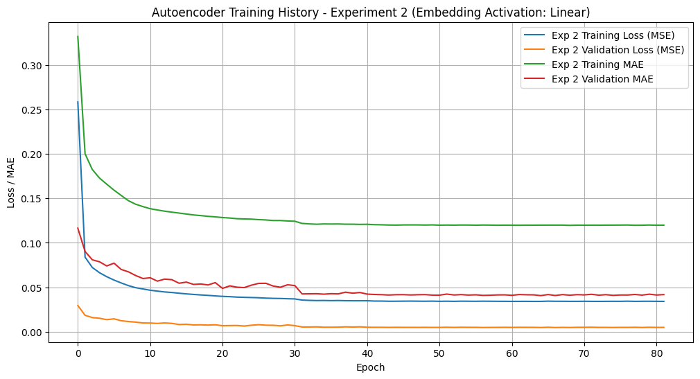

```
Evaluating on validation set after training (Experiment 2):
Experiment 2 - Final Validation MSE: 0.0048
Experiment 2 - Final Validation MAE: 0.0408
```

```python
# Plot training and validation loss/MAE over epochs for Experiment 2
plt.figure(figsize=(12, 6))
plt.plot(history_exp2.history['loss'], label='Exp 2 Training Loss (MSE)')
plt.plot(history_exp2.history['val_loss'], label='Exp 2 Validation Loss (MSE)')
plt.plot(history_exp2.history['mean_absolute_error'], label='Exp 2 Training MAE')
plt.plot(history_exp2.history['val_mean_absolute_error'], label='Exp 2 Validation MAE')
plt.title('Autoencoder Training History - Experiment 2 (Embedding Activation: Linear)')
plt.xlabel('Epoch')
plt.ylabel('Loss / MAE')
plt.legend()
plt.grid(True)
plt.show()

# Evaluate the autoencoder_exp2 on the validation data (if not already done)
# Assumes autoencoder_exp2 has best weights restored by EarlyStopping
if 'autoencoder_exp2' in locals() or 'autoencoder_exp2' in globals():
    print("Evaluating on validation set after training (Experiment 2):")
    val_loss_exp2, val_mae_exp2 = autoencoder_exp2.evaluate(X_val, X_val, verbose=0)
    print(f"Experiment 2 - Final Validation MSE: {val_loss_exp2:.4f}")
    print(f"Experiment 2 - Final Validation MAE: {val_mae_exp2:.4f}")
else:
    print("autoencoder_exp2 model not found. Cannot perform final evaluation.")
```

##### Conclusion from Experiments 1 and 2:

Experiment 2, which changed the embedding layer activation to 'linear' while keeping the embedding dimension at 10, achieved the lowest validation reconstruction error (both MSE and MAE) among the three models tested. This supports the hypothesis that allowing the embeddings to take on negative values can lead to a more expressive and effective representation space for this type of standardized input data.

Experiment 1 (Embedding Dim 16, 'relu') did not improve performance over the baseline (Embedding Dim 10, 'relu') and converged faster but to a slightly worse reconstruction error.

Based on reconstruction performance alone, the model from Experiment 2 (Embedding Dim 10, 'linear' activation) appears to be the best so far.

#### 3.6.3 Experiment 3: Adjusting Model Complexity (Neuron Count in Hidden Layers)

The current hidden layers in the encoder are `Dense(256)` and `Dense(128)`. Increasing the number of neurons (making layers "wider") provides the model with more capacity to learn complex patterns from the input features.

##### Hypothesis:

Wider hidden layers (e.g., 512 and 256 units) might enable the encoder to learn more intricate transformations, potentially improving the quality of the embeddings, especially if the underlying relationships in the data are highly complex. This must be balanced with the risk of overfitting, which `Dropout` and `BatchNormalization` help mitigate.

```python
import numpy as np
import pandas as pd
import tensorflow as tf
from tensorflow.keras.layers import Input, Dense, Dropout, BatchNormalization
from tensorflow.keras.models import Model
from tensorflow.keras.callbacks import EarlyStopping, ReduceLROnPlateau, ModelCheckpoint
from sklearn.model_selection import train_test_split
import matplotlib.pyplot as plt

print(f"TensorFlow Version: {tf.__version__}")

X_train, X_val = train_test_split(item_features_matrix, test_size=0.15, random_state=42)

INPUT_DIM = X_train.shape[1]
EMBEDDING_DIM_EXP3 = 10

# --- Encoder ---
input_layer_exp3 = Input(shape=(INPUT_DIM,), name='encoder_input_exp3')
# MODIFICATION FOR EXPERIMENT 3: Wider Dense layers
enc_exp3 = Dense(512, activation='relu')(input_layer_exp3) # Original was 256
enc_exp3 = BatchNormalization()(enc_exp3)
enc_exp3 = Dropout(0.3)(enc_exp3)
enc_exp3 = Dense(256, activation='relu')(enc_exp3) # Original was 128
enc_exp3 = BatchNormalization()(enc_exp3)
enc_exp3 = Dropout(0.3)(enc_exp3)
encoded_output_exp3 = Dense(EMBEDDING_DIM_EXP3, activation='linear', name='embedding_layer_exp3')(enc_exp3)

# --- Decoder (mirrored changes) ---
dec_exp3 = Dense(256, activation='relu')(encoded_output_exp3) # Original was 128
dec_exp3 = BatchNormalization()(dec_exp3)
dec_exp3 = Dropout(0.3)(dec_exp3)
dec_exp3 = Dense(512, activation='relu')(dec_exp3) # Original was 256
dec_exp3 = BatchNormalization()(dec_exp3)
dec_exp3 = Dropout(0.3)(dec_exp3)
decoded_output_exp3 = Dense(INPUT_DIM, activation='linear', name='decoder_output_exp3')(dec_exp3)

autoencoder_exp3 = Model(inputs=input_layer_exp3, outputs=decoded_output_exp3, name='autoencoder_exp3')
encoder_model_exp3 = Model(inputs=input_layer_exp3, outputs=encoded_output_exp3, name='encoder_exp3')
autoencoder_exp3.summary()

LEARNING_RATE = 0.001
OPTIMIZER_EXP3 = tf.keras.optimizers.Adam(learning_rate=LEARNING_RATE)
LOSS = 'mean_squared_error'
autoencoder_exp3.compile(optimizer=OPTIMIZER_EXP3, loss=LOSS, metrics=['mean_absolute_error'])

early_stopping_exp3 = EarlyStopping(monitor='val_loss', patience=15, restore_best_weights=True, verbose=1)
reduce_lr_exp3 = ReduceLROnPlateau(monitor='val_loss', factor=0.2, patience=7, min_lr=1e-6, verbose=1)
model_checkpoint_exp3 = ModelCheckpoint(filepath='best_autoencoder_model_exp3.keras',
                                     monitor='val_loss', save_best_only=True, verbose=1)
CALLBACKS_EXP3 = [early_stopping_exp3, reduce_lr_exp3, model_checkpoint_exp3]

EPOCHS = 200
BATCH_SIZE = 256
print(f"Starting Autoencoder training for Experiment 3 (Wider Layers)...")
history_exp3 = autoencoder_exp3.fit(X_train, X_train, epochs=EPOCHS, batch_size=BATCH_SIZE, shuffle=True, validation_data=(X_val, X_val), callbacks=CALLBACKS_EXP3, verbose=1)
print("\nAutoencoder training for Experiment 3 finished.")

val_loss_exp3, val_mae_exp3 = autoencoder_exp3.evaluate(X_val, X_val, verbose=0)
print(f"Experiment 3 - Final Validation MSE: {val_loss_exp3:.4f}, MAE: {val_mae_exp3:.4f}")
```

```
TensorFlow Version: 2.19.0
```

```
Model: "autoencoder_exp3"
```

```
┏━━━━━━━━━━━━━━━━━━━━━━━━━━━━━━━━━━━━━━┳━━━━━━━━━━━━━━━━━━━━━━━━━━━━━┳━━━━━━━━━━━━━━━━━┓
┃ Layer (type)                         ┃ Output Shape                ┃         Param # ┃
┡━━━━━━━━━━━━━━━━━━━━━━━━━━━━━━━━━━━━━━╇━━━━━━━━━━━━━━━━━━━━━━━━━━━━━╇━━━━━━━━━━━━━━━━━┩
│ encoder_input_exp3 (InputLayer)      │ (None, 18)                  │               0 │
├──────────────────────────────────────┼─────────────────────────────┼─────────────────┤
│ dense_12 (Dense)                     │ (None, 512)                 │           9,728 │
├──────────────────────────────────────┼─────────────────────────────┼─────────────────┤
│ batch_normalization_12               │ (None, 512)                 │           2,048 │
│ (BatchNormalization)                 │                             │                 │
├──────────────────────────────────────┼─────────────────────────────┼─────────────────┤
│ dropout_12 (Dropout)                 │ (None, 512)                 │               0 │
├──────────────────────────────────────┼─────────────────────────────┼─────────────────┤
│ dense_13 (Dense)                     │ (None, 256)                 │         131,328 │
├──────────────────────────────────────┼─────────────────────────────┼─────────────────┤
│ batch_normalization_13               │ (None, 256)                 │           1,024 │
│ (BatchNormalization)                 │                             │                 │
├──────────────────────────────────────┼─────────────────────────────┼─────────────────┤
│ dropout_13 (Dropout)                 │ (None, 256)                 │               0 │
├──────────────────────────────────────┼─────────────────────────────┼─────────────────┤
│ embedding_layer_exp3 (Dense)         │ (None, 10)                  │           2,570 │
├──────────────────────────────────────┼─────────────────────────────┼─────────────────┤
│ dense_14 (Dense)                     │ (None, 256)                 │           2,816 │
├──────────────────────────────────────┼─────────────────────────────┼─────────────────┤
│ batch_normalization_14               │ (None, 256)                 │           1,024 │
│ (BatchNormalization)                 │                             │                 │
├──────────────────────────────────────┼─────────────────────────────┼─────────────────┤
│ dropout_14 (Dropout)                 │ (None, 256)                 │               0 │
├──────────────────────────────────────┼─────────────────────────────┼─────────────────┤
│ dense_15 (Dense)                     │ (None, 512)                 │         131,584 │
├──────────────────────────────────────┼─────────────────────────────┼─────────────────┤
│ batch_normalization_15               │ (None, 512)                 │           2,048 │
│ (BatchNormalization)                 │                             │                 │
├──────────────────────────────────────┼─────────────────────────────┼─────────────────┤
│ dropout_15 (Dropout)                 │ (None, 512)                 │               0 │
├──────────────────────────────────────┼─────────────────────────────┼─────────────────┤
│ decoder_output_exp3 (Dense)          │ (None, 18)                  │           9,234 │
└──────────────────────────────────────┴─────────────────────────────┴─────────────────┘
```

```
 Total params: 293,404 (1.12 MB)
```

```
 Trainable params: 290,332 (1.11 MB)
```

```
 Non-trainable params: 3,072 (12.00 KB)
```

```
Starting Autoencoder training for Experiment 3 (Wider Layers)...
994/997 ━━━━━━━━━━━━━━━━━━━━ 0s 8ms/step - loss: 0.5055 - mean_absolute_error: 0.4573
Epoch 1: val_loss improved from inf to 0.01416, saving model to best_autoencoder_model_exp3.keras
997/997 ━━━━━━━━━━━━━━━━━━━━ 11s 8ms/step - loss: 0.5043 - mean_absolute_error: 0.4566 - val_loss: 0.0142 - val_mean_absolute_error: 0.0795 - learning_rate: 0.0010
996/997 ━━━━━━━━━━━━━━━━━━━━ 0s 7ms/step - loss: 0.0536 - mean_absolute_error: 0.1606
Epoch 2: val_loss improved from 0.01416 to 0.01302, saving model to best_autoencoder_model_exp3.keras
997/997 ━━━━━━━━━━━━━━━━━━━━ 8s 8ms/step - loss: 0.0536 - mean_absolute_error: 0.1606 - val_loss: 0.0130 - val_mean_absolute_error: 0.0745 - learning_rate: 0.0010
992/997 ━━━━━━━━━━━━━━━━━━━━ 0s 7ms/step - loss: 0.0469 - mean_absolute_error: 0.1489
Epoch 3: val_loss improved from 0.01302 to 0.01023, saving model to best_autoencoder_model_exp3.keras
997/997 ━━━━━━━━━━━━━━━━━━━━ 8s 8ms/step - loss: 0.0469 - mean_absolute_error: 0.1489 - val_loss: 0.0102 - val_mean_absolute_error: 0.0644 - learning_rate: 0.0010
996/997 ━━━━━━━━━━━━━━━━━━━━ 0s 7ms/step - loss: 0.0426 - mean_absolute_error: 0.1412
Epoch 4: val_loss improved from 0.01023 to 0.00971, saving model to best_autoencoder_model_exp3.keras
997/997 ━━━━━━━━━━━━━━━━━━━━ 10s 8ms/step - loss: 0.0426 - mean_absolute_error: 0.1412 - val_loss: 0.0097 - val_mean_absolute_error: 0.0642 - learning_rate: 0.0010
996/997 ━━━━━━━━━━━━━━━━━━━━ 0s 8ms/step - loss: 0.0393 - mean_absolute_error: 0.1355
Epoch 5: val_loss did not improve from 0.00971
997/997 ━━━━━━━━━━━━━━━━━━━━ 8s 8ms/step - loss: 0.0393 - mean_absolute_error: 0.1355 - val_loss: 0.0100 - val_mean_absolute_error: 0.0672 - learning_rate: 0.0010
995/997 ━━━━━━━━━━━━━━━━━━━━ 0s 8ms/step - loss: 0.0366 - mean_absolute_error: 0.1296
Epoch 6: val_loss improved from 0.00971 to 0.00735, saving model to best_autoencoder_model_exp3.keras
997/997 ━━━━━━━━━━━━━━━━━━━━ 8s 8ms/step - loss: 0.0366 - mean_absolute_error: 0.1296 - val_loss: 0.0073 - val_mean_absolute_error: 0.0564 - learning_rate: 0.0010
994/997 ━━━━━━━━━━━━━━━━━━━━ 0s 8ms/step - loss: 0.0335 - mean_absolute_error: 0.1220
Epoch 7: val_loss improved from 0.00735 to 0.00659, saving model to best_autoencoder_model_exp3.keras
997/997 ━━━━━━━━━━━━━━━━━━━━ 8s 8ms/step - loss: 0.0335 - mean_absolute_error: 0.1220 - val_loss: 0.0066 - val_mean_absolute_error: 0.0536 - learning_rate: 0.0010
995/997 ━━━━━━━━━━━━━━━━━━━━ 0s 8ms/step - loss: 0.0316 - mean_absolute_error: 0.1174
Epoch 8: val_loss improved from 0.00659 to 0.00593, saving model to best_autoencoder_model_exp3.keras
997/997 ━━━━━━━━━━━━━━━━━━━━ 8s 8ms/step - loss: 0.0316 - mean_absolute_error: 0.1174 - val_loss: 0.0059 - val_mean_absolute_error: 0.0493 - learning_rate: 0.0010
990/997 ━━━━━━━━━━━━━━━━━━━━ 0s 7ms/step - loss: 0.0301 - mean_absolute_error: 0.1140
Epoch 9: val_loss improved from 0.00593 to 0.00562, saving model to best_autoencoder_model_exp3.keras
997/997 ━━━━━━━━━━━━━━━━━━━━ 8s 8ms/step - loss: 0.0301 - mean_absolute_error: 0.1140 - val_loss: 0.0056 - val_mean_absolute_error: 0.0486 - learning_rate: 0.0010
991/997 ━━━━━━━━━━━━━━━━━━━━ 0s 7ms/step - loss: 0.0288 - mean_absolute_error: 0.1109
Epoch 10: val_loss did not improve from 0.00562
997/997 ━━━━━━━━━━━━━━━━━━━━ 8s 8ms/step - loss: 0.0288 - mean_absolute_error: 0.1109 - val_loss: 0.0060 - val_mean_absolute_error: 0.0497 - learning_rate: 0.0010
992/997 ━━━━━━━━━━━━━━━━━━━━ 0s 7ms/step - loss: 0.0283 - mean_absolute_error: 0.1097
Epoch 11: val_loss improved from 0.00562 to 0.00553, saving model to best_autoencoder_model_exp3.keras
997/997 ━━━━━━━━━━━━━━━━━━━━ 8s 8ms/step - loss: 0.0283 - mean_absolute_error: 0.1097 - val_loss: 0.0055 - val_mean_absolute_error: 0.0499 - learning_rate: 0.0010
993/997 ━━━━━━━━━━━━━━━━━━━━ 0s 7ms/step - loss: 0.0273 - mean_absolute_error: 0.1078
Epoch 12: val_loss improved from 0.00553 to 0.00493, saving model to best_autoencoder_model_exp3.keras
997/997 ━━━━━━━━━━━━━━━━━━━━ 10s 8ms/step - loss: 0.0273 - mean_absolute_error: 0.1078 - val_loss: 0.0049 - val_mean_absolute_error: 0.0429 - learning_rate: 0.0010
990/997 ━━━━━━━━━━━━━━━━━━━━ 0s 7ms/step - loss: 0.0268 - mean_absolute_error: 0.1060
Epoch 13: val_loss did not improve from 0.00493
997/997 ━━━━━━━━━━━━━━━━━━━━ 8s 8ms/step - loss: 0.0268 - mean_absolute_error: 0.1060 - val_loss: 0.0054 - val_mean_absolute_error: 0.0460 - learning_rate: 0.0010
```

[output cut: 204 more lines]

```
997/997 ━━━━━━━━━━━━━━━━━━━━ 9s 9ms/step - loss: 0.0193 - mean_absolute_error: 0.0907 - val_loss: 0.0017 - val_mean_absolute_error: 0.0241 - learning_rate: 1.0000e-06
994/997 ━━━━━━━━━━━━━━━━━━━━ 0s 8ms/step - loss: 0.0192 - mean_absolute_error: 0.0904
Epoch 79: val_loss did not improve from 0.00165
997/997 ━━━━━━━━━━━━━━━━━━━━ 9s 9ms/step - loss: 0.0192 - mean_absolute_error: 0.0904 - val_loss: 0.0017 - val_mean_absolute_error: 0.0244 - learning_rate: 1.0000e-06
991/997 ━━━━━━━━━━━━━━━━━━━━ 0s 8ms/step - loss: 0.0192 - mean_absolute_error: 0.0904
Epoch 80: val_loss did not improve from 0.00165
997/997 ━━━━━━━━━━━━━━━━━━━━ 9s 9ms/step - loss: 0.0192 - mean_absolute_error: 0.0904 - val_loss: 0.0017 - val_mean_absolute_error: 0.0241 - learning_rate: 1.0000e-06
995/997 ━━━━━━━━━━━━━━━━━━━━ 0s 9ms/step - loss: 0.0192 - mean_absolute_error: 0.0904
Epoch 81: val_loss did not improve from 0.00165
997/997 ━━━━━━━━━━━━━━━━━━━━ 9s 9ms/step - loss: 0.0192 - mean_absolute_error: 0.0904 - val_loss: 0.0017 - val_mean_absolute_error: 0.0242 - learning_rate: 1.0000e-06
Epoch 81: early stopping
Restoring model weights from the end of the best epoch: 66.

Autoencoder training for Experiment 3 finished.
Experiment 3 - Final Validation MSE: 0.0016, MAE: 0.0236
```

##### Analysis of Experiment 3 (Wider Hidden Layers):

**Best Performance:** The lowest validation loss (`val_loss`) was achieved at Epoch 66.

**Validation Metrics (at best epoch 66):**

- Validation MSE: 0.0016
- Validation MAE: 0.0236

**Training Behavior:**

- The model trained for 81 epochs before `EarlyStopping` triggered (with `patience=15`), indicating that the validation loss did not improve significantly for 15 consecutive epochs after Epoch 66.
- The `ReduceLROnPlateau` callback reduced the learning rate multiple times.
- The final validation metrics (MSE 0.0016, MAE 0.0236) are significantly lower than those from the baseline and previous experiments, indicating that increasing the width of the hidden layers, combined with the linear embedding activation, led to a much better reconstruction performance.

##### Comparison of Experiments:

| Experiment | Embedding Dim | Embedding Activation | Hidden Layers (Neurons) | Best Val MSE | Best Val MAE | Best Epoch | Training Epochs |
| --- | --- | --- | --- | --- | --- | --- | --- |
| Baseline | 10 | 'relu' | (256, 128) | 0.0064 | 0.0431 | 51 | 66 |
| Experiment 1 | 16 | 'relu' | (256, 128) | 0.0067 | 0.0588 | 11 | 26 |
| Experiment 2 | 10 | 'linear' | (256, 128) | 0.0048 | 0.0408 | 67 | 82 |
| Experiment 3 | 10 | 'linear' | (512, 256) | 0.0016 | 0.0236 | 66 | 81 |

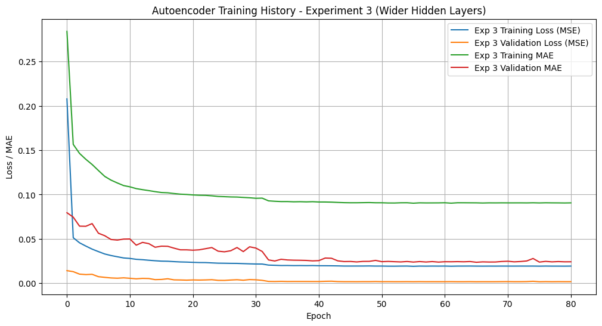

```
Evaluating on validation set after training (Experiment 3):
Experiment 3 - Final Validation MSE: 0.0016
Experiment 3 - Final Validation MAE: 0.0236
```

```python
# Plot training and validation loss/MAE over epochs for Experiment 3
plt.figure(figsize=(12, 6))
plt.plot(history_exp3.history['loss'], label='Exp 3 Training Loss (MSE)')
plt.plot(history_exp3.history['val_loss'], label='Exp 3 Validation Loss (MSE)')
plt.plot(history_exp3.history['mean_absolute_error'], label='Exp 3 Training MAE')
plt.plot(history_exp3.history['val_mean_absolute_error'], label='Exp 3 Validation MAE')
plt.title('Autoencoder Training History - Experiment 3 (Wider Hidden Layers)')
plt.xlabel('Epoch')
plt.ylabel('Loss / MAE')
plt.legend()
plt.grid(True)
plt.show()


if 'autoencoder_exp3' in locals() or 'autoencoder_exp3' in globals():
    print("Evaluating on validation set after training (Experiment 3):")
    val_loss_exp3, val_mae_exp3 = autoencoder_exp3.evaluate(X_val, X_val, verbose=0)
    print(f"Experiment 3 - Final Validation MSE: {val_loss_exp3:.4f}")
    print(f"Experiment 3 - Final Validation MAE: {val_mae_exp3:.4f}")
else:
    print("autoencoder_exp3 model not found. Cannot perform final evaluation.")
```

##### Conclusion from Experiments 1, 2, and 3:

Experiment 3, which used wider hidden layers (512, 256) and a linear embedding activation (from Experiment 2) while keeping the embedding dimension at 10, achieved the lowest validation reconstruction error (both MSE and MAE) by a significant margin. This indicates that increasing the model's capacity in the hidden layers, combined with the flexibility of linear embeddings, allowed it to learn a much better representation for reconstructing the input features.

Based on reconstruction performance, the model from Experiment 3 (Embedding Dim 10, 'linear' activation, Wider Layers) is the best performing model so far.

#### 3.6.4 Experiment 4: Tuning Dropout Rate

The previous experiments explored the impact of embedding dimension and embedding layer activation, with Experiment 3 (wider layers, linear embedding activation) showing the best reconstruction performance so far. This experiment focuses on another key regularization hyperparameter: the Dropout rate.

The current Dropout rate used in the baseline and previous experiments is 0.3. Dropout randomly sets a fraction of input units to 0 at each update during training, which helps prevent overfitting by making the network less reliant on specific neurons. Tuning this rate can impact the balance between model capacity and regularization.

##### Hypothesis:

Adjusting the Dropout rate from 0.3 to 0.2 might slightly reduce regularization, potentially allowing the model to learn slightly more complex patterns if the current rate is too aggressive, without significantly increasing overfitting, given the use of Batch Normalization. A lower rate could lead to a small improvement in reconstruction performance if the model was previously under-utilizing its capacity due to excessive dropout.

```python
# --- Define Autoencoder Architecture ---
INPUT_DIM = X_train.shape[1]
# Keep embedding dimension and activation from the best model so far (Experiment 3)
EMBEDDING_DIM_EXP4 = 10

# MODIFICATION FOR EXPERIMENT 4: Change Dropout rate
DROPOUT_RATE_EXP4 = 0.2 # Original was 0.3

# --- Encoder ---
input_layer_exp4 = Input(shape=(INPUT_DIM,), name='encoder_input_exp4')

# Keep wider Dense layers from Experiment 3
enc_exp4 = Dense(512, activation='relu')(input_layer_exp4) # From Experiment 3
enc_exp4 = BatchNormalization()(enc_exp4)
# Apply new Dropout rate
enc_exp4 = Dropout(DROPOUT_RATE_EXP4)(enc_exp4)

enc_exp4 = Dense(256, activation='relu')(enc_exp4) # From Experiment 3
enc_exp4 = BatchNormalization()(enc_exp4)
# Apply new Dropout rate
enc_exp4 = Dropout(DROPOUT_RATE_EXP4)(enc_exp4)

# Keep linear activation for embedding layer (from Experiment 2/3)
encoded_output_exp4 = Dense(EMBEDDING_DIM_EXP4, activation='linear', name='embedding_layer_exp4')(enc_exp4)

# --- Decoder (mirrored changes) ---
dec_exp4 = Dense(256, activation='relu')(encoded_output_exp4) # From Experiment 3
dec_exp4 = BatchNormalization()(dec_exp4)
# Apply new Dropout rate
dec_exp4 = Dropout(DROPOUT_RATE_EXP4)(dec_exp4)

dec_exp4 = Dense(512, activation='relu')(dec_exp4) # From Experiment 3
dec_exp4 = BatchNormalization()(dec_exp4)
# Apply new Dropout rate
dec_exp4 = Dropout(DROPOUT_RATE_EXP4)(dec_exp4)

decoded_output_exp4 = Dense(INPUT_DIM, activation='linear', name='decoder_output_exp4')(dec_exp4)

# --- Define Models ---
autoencoder_exp4 = Model(inputs=input_layer_exp4, outputs=decoded_output_exp4, name='autoencoder_exp4')
encoder_model_exp4 = Model(inputs=input_layer_exp4, outputs=encoded_output_exp4, name='encoder_exp4')

autoencoder_exp4.summary()

# --- Compile the Model ---
LEARNING_RATE = 0.001 # Keep learning rate
OPTIMIZER_EXP4 = tf.keras.optimizers.Adam(learning_rate=LEARNING_RATE)
LOSS = 'mean_squared_error' # Keep loss function
autoencoder_exp4.compile(optimizer=OPTIMIZER_EXP4, loss=LOSS, metrics=['mean_absolute_error'])

# --- Define Callbacks ---
# Use specific filenames for this experiment
early_stopping_exp4 = EarlyStopping(monitor='val_loss', patience=15, restore_best_weights=True, verbose=1)
reduce_lr_exp4 = ReduceLROnPlateau(monitor='val_loss', factor=0.2, patience=7, min_lr=1e-6, verbose=1)
model_checkpoint_exp4 = ModelCheckpoint(filepath='best_autoencoder_model_exp4.keras',
                                     monitor='val_loss', save_best_only=True, verbose=1)
CALLBACKS_EXP4 = [early_stopping_exp4, reduce_lr_exp4, model_checkpoint_exp4]

# --- Train the Autoencoder ---
EPOCHS = 200 # Keep max epochs
BATCH_SIZE = 256 # Keep batch size
print(f"Starting Autoencoder training for Experiment 4 (Dropout Rate: {DROPOUT_RATE_EXP4})...")
# The training output will appear below this cell when executed
history_exp4 = autoencoder_exp4.fit(
    X_train, X_train,
    epochs=EPOCHS,
    batch_size=BATCH_SIZE,
    shuffle=True,
    validation_data=(X_val, X_val),
    callbacks=CALLBACKS_EXP4,
    verbose=1
)
print("\nAutoencoder training for Experiment 4 finished.")

# --- Evaluate (After Training Completes) ---
# This evaluation will run after the fit method finishes
val_loss_exp4, val_mae_exp4 = autoencoder_exp4.evaluate(X_val, X_val, verbose=0)
print(f"Experiment 4 - Final Validation MSE: {val_loss_exp4:.4f}, MAE: {val_mae_exp4:.4f}")

# --- Extract Embeddings (After Training Completes) ---
# This extraction will run after the fit method finishes
# Ensure item_features_matrix is available from data loading
if 'item_features_matrix' in locals() or 'item_features_matrix' in globals():
    print("Generating embeddings for the entire sample dataset (Experiment 4)...")
    all_property_embeddings_exp4 = encoder_model_exp4.predict(item_features_matrix, batch_size=BATCH_SIZE)
    print(f"Shape of generated embeddings (Experiment 4): {all_property_embeddings_exp4.shape}")
    np.save('item_embeddings_exp4.npy', all_property_embeddings_exp4)
    print("Embeddings saved to 'item_embeddings_exp4.npy'")
    encoder_model_exp4.save('encoder_model_exp4.keras')
    print("Encoder model saved to 'encoder_model_exp4.keras'")
else:
    print("item_features_matrix not found. Skipping embedding extraction.")
```

```
Model: "autoencoder_exp4"
```

```
┏━━━━━━━━━━━━━━━━━━━━━━━━━━━━━━━━━━━━━━┳━━━━━━━━━━━━━━━━━━━━━━━━━━━━━┳━━━━━━━━━━━━━━━━━┓
┃ Layer (type)                         ┃ Output Shape                ┃         Param # ┃
┡━━━━━━━━━━━━━━━━━━━━━━━━━━━━━━━━━━━━━━╇━━━━━━━━━━━━━━━━━━━━━━━━━━━━━╇━━━━━━━━━━━━━━━━━┩
│ encoder_input_exp4 (InputLayer)      │ (None, 18)                  │               0 │
├──────────────────────────────────────┼─────────────────────────────┼─────────────────┤
│ dense_16 (Dense)                     │ (None, 512)                 │           9,728 │
├──────────────────────────────────────┼─────────────────────────────┼─────────────────┤
│ batch_normalization_16               │ (None, 512)                 │           2,048 │
│ (BatchNormalization)                 │                             │                 │
├──────────────────────────────────────┼─────────────────────────────┼─────────────────┤
│ dropout_16 (Dropout)                 │ (None, 512)                 │               0 │
├──────────────────────────────────────┼─────────────────────────────┼─────────────────┤
│ dense_17 (Dense)                     │ (None, 256)                 │         131,328 │
├──────────────────────────────────────┼─────────────────────────────┼─────────────────┤
│ batch_normalization_17               │ (None, 256)                 │           1,024 │
│ (BatchNormalization)                 │                             │                 │
├──────────────────────────────────────┼─────────────────────────────┼─────────────────┤
│ dropout_17 (Dropout)                 │ (None, 256)                 │               0 │
├──────────────────────────────────────┼─────────────────────────────┼─────────────────┤
│ embedding_layer_exp4 (Dense)         │ (None, 10)                  │           2,570 │
├──────────────────────────────────────┼─────────────────────────────┼─────────────────┤
│ dense_18 (Dense)                     │ (None, 256)                 │           2,816 │
├──────────────────────────────────────┼─────────────────────────────┼─────────────────┤
│ batch_normalization_18               │ (None, 256)                 │           1,024 │
│ (BatchNormalization)                 │                             │                 │
├──────────────────────────────────────┼─────────────────────────────┼─────────────────┤
│ dropout_18 (Dropout)                 │ (None, 256)                 │               0 │
├──────────────────────────────────────┼─────────────────────────────┼─────────────────┤
│ dense_19 (Dense)                     │ (None, 512)                 │         131,584 │
├──────────────────────────────────────┼─────────────────────────────┼─────────────────┤
│ batch_normalization_19               │ (None, 512)                 │           2,048 │
│ (BatchNormalization)                 │                             │                 │
├──────────────────────────────────────┼─────────────────────────────┼─────────────────┤
│ dropout_19 (Dropout)                 │ (None, 512)                 │               0 │
├──────────────────────────────────────┼─────────────────────────────┼─────────────────┤
│ decoder_output_exp4 (Dense)          │ (None, 18)                  │           9,234 │
└──────────────────────────────────────┴─────────────────────────────┴─────────────────┘
```

```
 Total params: 293,404 (1.12 MB)
```

```
 Trainable params: 290,332 (1.11 MB)
```

```
 Non-trainable params: 3,072 (12.00 KB)
```

```
Starting Autoencoder training for Experiment 4 (Dropout Rate: 0.2)...
996/997 ━━━━━━━━━━━━━━━━━━━━ 0s 7ms/step - loss: 0.3924 - mean_absolute_error: 0.4078
Epoch 1: val_loss improved from inf to 0.01200, saving model to best_autoencoder_model_exp4.keras
997/997 ━━━━━━━━━━━━━━━━━━━━ 11s 8ms/step - loss: 0.3920 - mean_absolute_error: 0.4075 - val_loss: 0.0120 - val_mean_absolute_error: 0.0709 - learning_rate: 0.0010
993/997 ━━━━━━━━━━━━━━━━━━━━ 0s 8ms/step - loss: 0.0392 - mean_absolute_error: 0.1374
Epoch 2: val_loss improved from 0.01200 to 0.00945, saving model to best_autoencoder_model_exp4.keras
997/997 ━━━━━━━━━━━━━━━━━━━━ 8s 8ms/step - loss: 0.0392 - mean_absolute_error: 0.1374 - val_loss: 0.0094 - val_mean_absolute_error: 0.0649 - learning_rate: 0.0010
993/997 ━━━━━━━━━━━━━━━━━━━━ 0s 7ms/step - loss: 0.0327 - mean_absolute_error: 0.1250
Epoch 3: val_loss improved from 0.00945 to 0.00693, saving model to best_autoencoder_model_exp4.keras
997/997 ━━━━━━━━━━━━━━━━━━━━ 8s 8ms/step - loss: 0.0327 - mean_absolute_error: 0.1250 - val_loss: 0.0069 - val_mean_absolute_error: 0.0556 - learning_rate: 0.0010
995/997 ━━━━━━━━━━━━━━━━━━━━ 0s 7ms/step - loss: 0.0292 - mean_absolute_error: 0.1180
Epoch 4: val_loss did not improve from 0.00693
997/997 ━━━━━━━━━━━━━━━━━━━━ 8s 8ms/step - loss: 0.0292 - mean_absolute_error: 0.1180 - val_loss: 0.0073 - val_mean_absolute_error: 0.0559 - learning_rate: 0.0010
995/997 ━━━━━━━━━━━━━━━━━━━━ 0s 7ms/step - loss: 0.0272 - mean_absolute_error: 0.1127
Epoch 5: val_loss improved from 0.00693 to 0.00510, saving model to best_autoencoder_model_exp4.keras
997/997 ━━━━━━━━━━━━━━━━━━━━ 8s 8ms/step - loss: 0.0272 - mean_absolute_error: 0.1127 - val_loss: 0.0051 - val_mean_absolute_error: 0.0488 - learning_rate: 0.0010
988/997 ━━━━━━━━━━━━━━━━━━━━ 0s 7ms/step - loss: 0.0249 - mean_absolute_error: 0.1066
Epoch 6: val_loss improved from 0.00510 to 0.00484, saving model to best_autoencoder_model_exp4.keras
997/997 ━━━━━━━━━━━━━━━━━━━━ 8s 8ms/step - loss: 0.0249 - mean_absolute_error: 0.1066 - val_loss: 0.0048 - val_mean_absolute_error: 0.0477 - learning_rate: 0.0010
991/997 ━━━━━━━━━━━━━━━━━━━━ 0s 8ms/step - loss: 0.0232 - mean_absolute_error: 0.1023
Epoch 7: val_loss did not improve from 0.00484
997/997 ━━━━━━━━━━━━━━━━━━━━ 8s 8ms/step - loss: 0.0232 - mean_absolute_error: 0.1023 - val_loss: 0.0052 - val_mean_absolute_error: 0.0467 - learning_rate: 0.0010
992/997 ━━━━━━━━━━━━━━━━━━━━ 0s 8ms/step - loss: 0.0219 - mean_absolute_error: 0.0987
Epoch 8: val_loss improved from 0.00484 to 0.00412, saving model to best_autoencoder_model_exp4.keras
997/997 ━━━━━━━━━━━━━━━━━━━━ 8s 8ms/step - loss: 0.0219 - mean_absolute_error: 0.0987 - val_loss: 0.0041 - val_mean_absolute_error: 0.0445 - learning_rate: 0.0010
994/997 ━━━━━━━━━━━━━━━━━━━━ 0s 7ms/step - loss: 0.0212 - mean_absolute_error: 0.0967
Epoch 9: val_loss did not improve from 0.00412
997/997 ━━━━━━━━━━━━━━━━━━━━ 8s 8ms/step - loss: 0.0212 - mean_absolute_error: 0.0967 - val_loss: 0.0044 - val_mean_absolute_error: 0.0436 - learning_rate: 0.0010
996/997 ━━━━━━━━━━━━━━━━━━━━ 0s 7ms/step - loss: 0.0205 - mean_absolute_error: 0.0945
Epoch 10: val_loss improved from 0.00412 to 0.00365, saving model to best_autoencoder_model_exp4.keras
997/997 ━━━━━━━━━━━━━━━━━━━━ 8s 8ms/step - loss: 0.0205 - mean_absolute_error: 0.0945 - val_loss: 0.0036 - val_mean_absolute_error: 0.0398 - learning_rate: 0.0010
994/997 ━━━━━━━━━━━━━━━━━━━━ 0s 7ms/step - loss: 0.0195 - mean_absolute_error: 0.0921
Epoch 11: val_loss improved from 0.00365 to 0.00339, saving model to best_autoencoder_model_exp4.keras
997/997 ━━━━━━━━━━━━━━━━━━━━ 8s 8ms/step - loss: 0.0195 - mean_absolute_error: 0.0921 - val_loss: 0.0034 - val_mean_absolute_error: 0.0390 - learning_rate: 0.0010
994/997 ━━━━━━━━━━━━━━━━━━━━ 0s 8ms/step - loss: 0.0193 - mean_absolute_error: 0.0914
Epoch 12: val_loss improved from 0.00339 to 0.00322, saving model to best_autoencoder_model_exp4.keras
997/997 ━━━━━━━━━━━━━━━━━━━━ 8s 8ms/step - loss: 0.0193 - mean_absolute_error: 0.0914 - val_loss: 0.0032 - val_mean_absolute_error: 0.0379 - learning_rate: 0.0010
993/997 ━━━━━━━━━━━━━━━━━━━━ 0s 7ms/step - loss: 0.0187 - mean_absolute_error: 0.0900
Epoch 13: val_loss did not improve from 0.00322
997/997 ━━━━━━━━━━━━━━━━━━━━ 8s 8ms/step - loss: 0.0187 - mean_absolute_error: 0.0900 - val_loss: 0.0036 - val_mean_absolute_error: 0.0382 - learning_rate: 0.0010
```

[output cut: 236 more lines]

```
Epoch 89: val_loss did not improve from 0.00094
997/997 ━━━━━━━━━━━━━━━━━━━━ 10s 10ms/step - loss: 0.0134 - mean_absolute_error: 0.0766 - val_loss: 9.8146e-04 - val_mean_absolute_error: 0.0180 - learning_rate: 1.0000e-06
992/997 ━━━━━━━━━━━━━━━━━━━━ 0s 9ms/step - loss: 0.0134 - mean_absolute_error: 0.0767
Epoch 90: val_loss did not improve from 0.00094
997/997 ━━━━━━━━━━━━━━━━━━━━ 10s 10ms/step - loss: 0.0134 - mean_absolute_error: 0.0767 - val_loss: 0.0010 - val_mean_absolute_error: 0.0181 - learning_rate: 1.0000e-06
Epoch 90: early stopping
Restoring model weights from the end of the best epoch: 75.

Autoencoder training for Experiment 4 finished.
Experiment 4 - Final Validation MSE: 0.0009, MAE: 0.0176
Generating embeddings for the entire sample dataset (Experiment 4)...
1172/1172 ━━━━━━━━━━━━━━━━━━━━ 2s 1ms/step
Shape of generated embeddings (Experiment 4): (300000, 10)
Embeddings saved to 'item_embeddings_exp4.npy'
Encoder model saved to 'encoder_model_exp4.keras'
```

##### Analysis of Experiment 4 (Adjusting Dropout Rate):

**Best Performance:** The lowest validation loss (`val_loss`) was achieved at Epoch 75.

**Validation Metrics (at best epoch 75):**

- Validation MSE: 0.0009
- Validation MAE: 0.0176

**Training Behavior:**

- The model trained for 90 epochs before `EarlyStopping` triggered (with `patience=15`), indicating that the validation loss did not improve significantly for 15 consecutive epochs after Epoch 75.
- The `ReduceLROnPlateau` callback reduced the learning rate multiple times.
- The final validation metrics (MSE 0.0009, MAE 0.0176) are the lowest observed so far across all experiments, showing a further improvement over Experiment 3.

##### Comparison of Experiments:

| Experiment | Embedding Dim | Embedding Activation | Hidden Layers (Neurons) | Dropout Rate | Best Val MSE | Best Val MAE | Best Epoch | Training Epochs |
| --- | --- | --- | --- | --- | --- | --- | --- | --- |
| Baseline | 10 | 'relu' | (256, 128) | 0.3 | 0.0064 | 0.0431 | 51 | 66 |
| Experiment 1 | 16 | 'relu' | (256, 128) | 0.3 | 0.0067 | 0.0588 | 11 | 26 |
| Experiment 2 | 10 | 'linear' | (256, 128) | 0.3 | 0.0048 | 0.0408 | 67 | 82 |
| Experiment 3 | 10 | 'linear' | (512, 256) | 0.3 | 0.0016 | 0.0236 | 66 | 81 |
| Experiment 4 | 10 | 'linear' | (512, 256) | 0.2 | 0.0009 | 0.0176 | 75 | 90 |

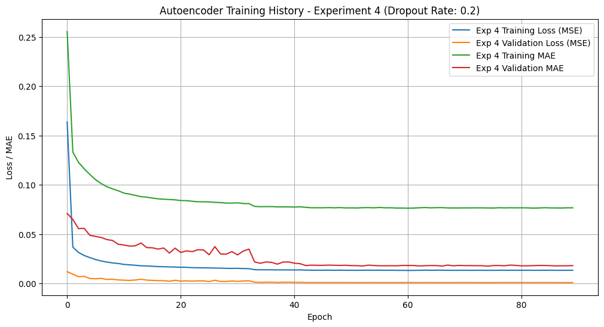

```
Evaluating on validation set after training (Experiment 4):
Experiment 4 - Final Validation MSE: 0.0009
Experiment 4 - Final Validation MAE: 0.0176
```

```python
import matplotlib.pyplot as plt

if 'history_exp4' in locals() or 'history_exp4' in globals():
    plt.figure(figsize=(12, 6))
    plt.plot(history_exp4.history['loss'], label='Exp 4 Training Loss (MSE)')
    plt.plot(history_exp4.history['val_loss'], label='Exp 4 Validation Loss (MSE)')
    plt.plot(history_exp4.history['mean_absolute_error'], label='Exp 4 Training MAE')
    plt.plot(history_exp4.history['val_mean_absolute_error'], label='Exp 4 Validation MAE')
    plt.title('Autoencoder Training History - Experiment 4 (Dropout Rate: 0.2)')
    plt.xlabel('Epoch')
    plt.ylabel('Loss / MAE')
    plt.legend()
    plt.grid(True)
    plt.show()
else:
    print("history_exp4 variable not found. Cannot plot training history.")




if 'autoencoder_exp4' in locals() or 'autoencoder_exp4' in globals():
    print("Evaluating on validation set after training (Experiment 4):")
    # Ensure X_val is available
    if 'X_val' in locals() or 'X_val' in globals():
        val_loss_exp4, val_mae_exp4 = autoencoder_exp4.evaluate(X_val, X_val, verbose=0)
        print(f"Experiment 4 - Final Validation MSE: {val_loss_exp4:.4f}")
        print(f"Experiment 4 - Final Validation MAE: {val_mae_exp4:.4f}")
    else:
        print("X_val data not found. Cannot perform final evaluation.")
else:
    print("autoencoder_exp4 model not found. Cannot perform final evaluation.")
```

##### Conclusion from Experiment 4:

Experiment 4, with a Dropout rate of 0.2, combined with the wider hidden layers and linear embedding activation from Experiment 3, achieved the lowest validation reconstruction error (MSE: 0.0009, MAE: 0.0176) among all experiments. This suggests that slightly reducing the regularization from 0.3 to 0.2 allowed the model to learn a slightly better representation for reconstruction.

Based on reconstruction performance, the model from Experiment 4 (Embedding Dim 10, 'linear' activation, Wider Layers, Dropout 0.2) is the best performing model so far.

### 3.7 Qualitative Evaluation of Best Model Embeddings

We have conducted several experiments to improve the Autoencoder model's reconstruction performance, with Experiment 4 (Embedding Dim 10, Linear Activation, Wider Layers, Dropout 0.2) yielding the lowest validation MSE and MAE. While these metrics are important indicators of the model's ability to compress and reconstruct the input data, the ultimate goal is to learn embeddings that capture meaningful relationships between properties for recommendation purposes.

#### 3.7.1 Perform Qualitative Evaluation

In this section, we will perform a qualitative evaluation to assess whether the embeddings generated by the best model (Experiment 4) result in intuitively similar properties. This involves:

1. Using the encoder model from Experiment 4 to generate embeddings for the 300k sample dataset.
2. Calculating item-item cosine similarity based on these new embeddings.
3. Structuring these similarities into a fast in-memory lookup dictionary.
4. Selecting a few sample properties from the original (or sampled) dataset.
5. Retrieving their most similar properties using the new embedding-based lookup.
6. Examining the original preprocessed features of the source property and its most similar counterparts to see if their attributes align intuitively (e.g., similar price range, number of beds/baths, location characteristics).

This qualitative check complements the quantitative reconstruction metrics and provides insight into the practical utility of the learned embeddings for content-based recommendations.

```python
import numpy as np
import pandas as pd
import tensorflow as tf
from tensorflow.keras.models import load_model
from sklearn.metrics.pairwise import cosine_similarity
from sklearn.metrics.pairwise import pairwise_distances_chunked

import time
import os

# --- Configuration ---
# Filename for the best encoder model from Experiment 4
BEST_ENCODER_MODEL_PATH = 'encoder_model_exp4.keras' # Ensure this matches the filename used in Part 26

# Filename for the sampled data (needed to get original features for display)
SAMPLED_DATA_FILENAME = 'realtor_data_sample_300k.csv'

# Filename to save/load the embedding similarity results for this evaluation
EMBEDDING_SIMILARITY_EVAL_FILENAME = 'item_embedding_similarities_exp4_eval.parquet'

# Number of similar items to find and store for each item (should match N_similar used previously, e.g. 50)
N_SIMILAR_EVAL = 50 # Use the same N_similar as in previous similarity calculations

# Number of sample items to display for qualitative check
NUM_QUALITATIVE_SAMPLES = 5

# --- Load Data ---
try:
    print(f"Loading sampled data from '{SAMPLED_DATA_FILENAME}'...")
    df_sample = pd.read_csv(SAMPLED_DATA_FILENAME)
    print(f"Successfully loaded {len(df_sample)} rows.")

    # Ensure selected_features is defined - consistent with previous parts
    selected_features = [
        'price', 'bed', 'bath', 'acre_lot', 'house_size', 'has_prev_sale',
        'brokered_by_encoded', 'status_for_sale', 'status_ready_to_build',
        'status_sold', 'city_encoded', 'state_encoded', 'zip_code_encoded',
        'price_range_<100k', 'price_range_100k-300k', 'price_range_300k-600k',
        'price_range_600k-1M', 'price_range_1M+'] # Example features, use your actual list

    # Create the feature matrix from the loaded sample data
    item_features_matrix = df_sample[selected_features].values.astype(np.float64)
    print(f"Shape of item_features_matrix: {item_features_matrix.shape}")

except FileNotFoundError:
    print(f"Error: Sampled data file '{SAMPLED_DATA_FILENAME}' not found.")
    print("Please ensure the data sampling step (Part 3.1.0) was run and saved the file.")
    df_sample = None
    item_features_matrix = None
except Exception as e:
    print(f"An error occurred while loading sampled data: {e}")
    df_sample = None
    item_features_matrix = None


# --- Load Best Encoder Model (from Experiment 4) ---
encoder_model_exp4 = None
if os.path.exists(BEST_ENCODER_MODEL_PATH):
    try:
        print(f"\nLoading best encoder model from '{BEST_ENCODER_MODEL_PATH}'...")
        # Custom objects might be needed if you used custom layers/activations,
        # but for standard layers, load_model should work directly.
        encoder_model_exp4 = load_model(BEST_ENCODER_MODEL_PATH)
        print("Successfully loaded encoder model.")
        # Optional: Print model summary to confirm architecture
        # encoder_model_exp4.summary()
    except Exception as e:
        print(f"Error loading encoder model: {e}")
else:
    print(f"Error: Best encoder model file '{BEST_ENCODER_MODEL_PATH}' not found.")
    print("Please ensure Experiment 4 training was run and saved the model.")


# --- Generate Embeddings using the Best Model ---
item_embeddings_exp4 = None
if encoder_model_exp4 is not None and item_features_matrix is not None:
    print("\nGenerating embeddings using the best encoder model (Experiment 4)...")
    BATCH_SIZE = 256 # Use the same batch size as training
    try:
        item_embeddings_exp4 = encoder_model_exp4.predict(item_features_matrix, batch_size=BATCH_SIZE)
        print(f"Shape of generated embeddings: {item_embeddings_exp4.shape}")
    except Exception as e:
        print(f"Error generating embeddings: {e}")
        item_embeddings_exp4 = None
else:
    print("\nSkipping embedding generation as encoder model or data is not available.")


# --- Calculate Item Similarity based on Experiment 4 Embeddings ---
# This is similar to Part 3.5.9, but using the new embeddings
item_embedding_similarity_lookup_eval = {}

if item_embeddings_exp4 is not None:
    # Check if the similarity results file already exists for this evaluation
    if os.path.exists(EMBEDDING_SIMILARITY_EVAL_FILENAME):
        print(f"\nEmbedding similarity results file for Experiment 4 evaluation '{EMBEDDING_SIMILARITY_EVAL_FILENAME}' already exists. Reading from file.")
        try:
            similarity_df_embeddings_eval = pd.read_parquet(EMBEDDING_SIMILARITY_EVAL_FILENAME)
            print(f"Loaded {len(similarity_df_embeddings_eval)} embedding similarity pairs for evaluation.")

            # Build the lookup dictionary from the loaded DataFrame
            if not similarity_df_embeddings_eval.empty:
                 print("Building lookup dictionary from loaded data...")
                 similarity_df_embeddings_eval['source_item_index'] = similarity_df_embeddings_eval['source_item_index'].astype(int)
                 similarity_df_embeddings_eval['similar_item_index'] = similarity_df_embeddings_eval['similar_item_index'].astype(int)
                 similarity_df_embeddings_eval['similarity_score'] = similarity_df_embeddings_eval['similarity_score'].astype(float)

                 for source_idx, group in similarity_df_embeddings_eval.groupby('source_item_index'):
                     item_embedding_similarity_lookup_eval[source_idx] = list(zip(
                         group['similar_item_index'],
                         group['similarity_score']
                     ))
                 print(f"Lookup dictionary built with {len(item_embedding_similarity_lookup_eval)} source items.")
            else:
                 print("Loaded similarity DataFrame is empty.")


        except ImportError:
             print("Parquet libraries (pyarrow or fastparquet) not found. Cannot load similarity data.")
             similarity_df_embeddings_eval = None
             item_embedding_similarity_lookup_eval = {} # Ensure lookup is empty
        except Exception as e:
             print(f"An error occurred while loading similarity data: {e}")
             similarity_df_embeddings_eval = None
             item_embedding_similarity_lookup_eval = {} # Ensure lookup is empty
```

```python
    else:
        print(f"\nCalculating chunked embedding similarity for Experiment 4 embeddings...")
        print(f"Will find Top {N_SIMILAR_EVAL} similar items per item.")

        top_n_embedding_similarities_list_eval = [] # Initialize list to store results
        start_time = time.time() # Start timing the process
        total_items = item_embeddings_exp4.shape[0]
        processed_items_count = 0

        # Use pairwise_distances_chunked, similar to Part 3.5.9
        # Ensure embeddings are float64 for sklearn
        if item_embeddings_exp4.dtype != np.float64:
             item_embeddings_exp4 = item_embeddings_exp4.astype(np.float64)
             print(f"Embeddings converted to dtype: {item_embeddings_exp4.dtype}")

        # Adjust working_memory based on your system if needed
        memory_limit_mb = 1024 # Example: Try setting a soft limit of 1GB per thread

        for i, distances_chunk in enumerate(pairwise_distances_chunked(
                                                item_embeddings_exp4, # Y is implicitly item_embeddings_exp4
                                                metric='cosine',
                                                n_jobs=-1, # Use all available CPU cores
                                                working_memory=memory_limit_mb,
                                                reduce_func=None # Get the full distance sub-matrix for the chunk
                                            )):

            similarities_chunk = 1 - distances_chunk # Convert cosine distances to similarities

            num_source_items_in_this_chunk = similarities_chunk.shape[0]
            source_item_global_indices = np.arange(
                processed_items_count,
                processed_items_count + num_source_items_in_this_chunk
            )

            for local_idx_in_chunk, source_item_global_idx in enumerate(source_item_global_indices):
                item_similarities = similarities_chunk[local_idx_in_chunk, :]
                sorted_indices_all_items = item_similarities.argsort()[::-1]
                relevant_sorted_indices = sorted_indices_all_items[sorted_indices_all_items != source_item_global_idx]

                top_n_target_indices = relevant_sorted_indices[:N_SIMILAR_EVAL]
                top_n_scores = item_similarities[top_n_target_indices]

                for k_loop_idx in range(len(top_n_target_indices)):
                    target_item_global_idx = top_n_target_indices[k_loop_idx]
                    score = top_n_scores[k_loop_idx]
                    top_n_embedding_similarities_list_eval.append((source_item_global_idx, target_item_global_idx, score))

            processed_items_count += num_source_items_in_this_chunk

            # Print progress
            if (i + 1) % 10 == 0 or processed_items_count >= total_items: # Adjust print frequency
                elapsed_time = time.time() - start_time
                estimated_total_time = (elapsed_time / processed_items_count) * total_items if processed_items_count > 0 else 0
                print(f"Processed {processed_items_count}/{total_items} source items. "
                      f"(Internal scikit-learn chunk iteration: {i + 1}). "
                      f"Elapsed: {elapsed_time:.2f}s. Estimated Total: {estimated_total_time:.2f}s")

            if processed_items_count >= total_items:
                print("All source items processed.")
                break

        end_time = time.time()
        total_elapsed_time = end_time - start_time

        print(f"\nChunked embedding similarity calculation finished for Experiment 4 embeddings.")
        print(f"Total time taken: {total_elapsed_time:.2f} seconds ({total_elapsed_time/60:.2f} minutes)")
        print(f"Number of embedding similarity pairs stored: {len(top_n_embedding_similarities_list_eval)}")

        # Export the Embedding Similarity Results
        print(f"Exporting embedding similarity results to '{EMBEDDING_SIMILARITY_EVAL_FILENAME}'...")
        similarity_df_embeddings_eval = pd.DataFrame(top_n_embedding_similarities_list_eval, columns=['source_item_index', 'similar_item_index', 'similarity_score'])

        try:
            similarity_df_embeddings_eval.to_parquet(EMBEDDING_SIMILARITY_EVAL_FILENAME, index=False)
            print(f"Embedding similarity results export complete (Parquet format to '{EMBEDDING_SIMILARITY_EVAL_FILENAME}').")
        except ImportError:
            print("Parquet libraries (pyarrow or fastparquet) not found. Saving to CSV instead.")
            embedding_similarity_results_filename_csv = EMBEDDING_SIMILARITY_EVAL_FILENAME.replace('.parquet', '.csv')
            similarity_df_embeddings_eval.to_csv(embedding_similarity_results_filename_csv, index=False)
            print(f"Embedding similarity results export complete (CSV format) to '{embedding_similarity_results_filename_csv}').")

        # Build the lookup dictionary from the newly created DataFrame
        if not similarity_df_embeddings_eval.empty:
            print("Building lookup dictionary from newly calculated data...")
            similarity_df_embeddings_eval['source_item_index'] = similarity_df_embeddings_eval['source_item_index'].astype(int)
            similarity_df_embeddings_eval['similar_item_index'] = similarity_df_embeddings_eval['similar_item_index'].astype(int)
            similarity_df_embeddings_eval['similarity_score'] = similarity_df_embeddings_eval['similarity_score'].astype(float)

            for source_idx, group in similarity_df_embeddings_eval.groupby('source_item_index'):
                item_embedding_similarity_lookup_eval[source_idx] = list(zip(
                    group['similar_item_index'],
                    group['similarity_score']
                ))
            print(f"Lookup dictionary built with {len(item_embedding_similarity_lookup_eval)} source items.")
        else:
             print("Newly calculated similarity DataFrame is empty.")

else:
    print("\nSkipping embedding similarity calculation and lookup generation as embeddings are not available.")
```

```python
# --- Perform Qualitative Check ---
if item_embedding_similarity_lookup_eval and df_sample is not None:
    print(f"\nPerforming qualitative check with {NUM_QUALITATIVE_SAMPLES} sample items...")

    # Get a few random sample item indices from the keys of the lookup
    if len(item_embedding_similarity_lookup_eval) >= NUM_QUALITATIVE_SAMPLES:
        sample_indices = np.random.choice(list(item_embedding_similarity_lookup_eval.keys()), size=NUM_QUALITATIVE_SAMPLES, replace=False)
    elif len(item_embedding_similarity_lookup_eval) > 0:
        sample_indices = list(item_embedding_similarity_lookup_eval.keys()) # Use all available if less than requested
        print(f"Warning: Only {len(sample_indices)} items available in lookup for qualitative check.")
    else:
        sample_indices = []
        print("No items available in lookup for qualitative check.")


    for source_idx in sample_indices:
        print(f"\n--- Source Item Index: {source_idx} ---")
        # Retrieve original features for the source item
        source_item_features = df_sample.iloc[source_idx][selected_features]
        print("Source Item Features:")
        print(source_item_features)

        print(f"\nTop {min(5, N_SIMILAR_EVAL)} Similar Items (Embedding-Based):") # Display top 5 similar items
        similar_items_list = item_embedding_similarity_lookup_eval.get(source_idx, [])

        if similar_items_list:
            # Display details for the top few similar items
            num_to_display = min(5, len(similar_items_list))
            for i in range(num_to_display):
                similar_item_idx, similarity_score = similar_items_list[i]
                print(f"  - Similar Item Index: {similar_item_idx}, Similarity Score: {similarity_score:.4f}")
                # Retrieve original features for the similar item
                similar_item_features = df_sample.iloc[similar_item_idx][selected_features]
                print("    Similar Item Features:")
                print(similar_item_features)
        else:
            print("  No similar items found in the lookup.")

else:
    print("\nSkipping qualitative check as lookup or sample data is not available.")
```

```
Loading sampled data from 'realtor_data_sample_300k.csv'...
Successfully loaded 300000 rows.
Shape of item_features_matrix: (300000, 18)

Loading best encoder model from 'encoder_model_exp4.keras'...
Successfully loaded encoder model.

Generating embeddings using the best encoder model (Experiment 4)...
1172/1172 ━━━━━━━━━━━━━━━━━━━━ 1s 1ms/step
Shape of generated embeddings: (300000, 10)

Calculating chunked embedding similarity for Experiment 4 embeddings...
Will find Top 50 similar items per item.
Embeddings converted to dtype: float64
Processed 4470/300000 source items. (Internal scikit-learn chunk iteration: 10). Elapsed: 111.66s. Estimated Total: 7494.00s
Processed 8940/300000 source items. (Internal scikit-learn chunk iteration: 20). Elapsed: 211.33s. Estimated Total: 7091.49s
Processed 13410/300000 source items. (Internal scikit-learn chunk iteration: 30). Elapsed: 309.72s. Estimated Total: 6928.96s
Processed 17880/300000 source items. (Internal scikit-learn chunk iteration: 40). Elapsed: 408.88s. Estimated Total: 6860.46s
Processed 22350/300000 source items. (Internal scikit-learn chunk iteration: 50). Elapsed: 507.75s. Estimated Total: 6815.48s
Processed 26820/300000 source items. (Internal scikit-learn chunk iteration: 60). Elapsed: 617.20s. Estimated Total: 6903.83s
Processed 31290/300000 source items. (Internal scikit-learn chunk iteration: 70). Elapsed: 726.06s. Estimated Total: 6961.24s
Processed 35760/300000 source items. (Internal scikit-learn chunk iteration: 80). Elapsed: 826.42s. Estimated Total: 6933.03s
Processed 40230/300000 source items. (Internal scikit-learn chunk iteration: 90). Elapsed: 925.53s. Estimated Total: 6901.83s
Processed 44700/300000 source items. (Internal scikit-learn chunk iteration: 100). Elapsed: 1024.73s. Estimated Total: 6877.36s
Processed 49170/300000 source items. (Internal scikit-learn chunk iteration: 110). Elapsed: 1123.86s. Estimated Total: 6857.00s
Processed 53640/300000 source items. (Internal scikit-learn chunk iteration: 120). Elapsed: 1222.45s. Estimated Total: 6836.99s
Processed 58110/300000 source items. (Internal scikit-learn chunk iteration: 130). Elapsed: 1321.02s. Estimated Total: 6819.91s
Processed 62580/300000 source items. (Internal scikit-learn chunk iteration: 140). Elapsed: 1419.53s. Estimated Total: 6805.02s
Processed 67050/300000 source items. (Internal scikit-learn chunk iteration: 150). Elapsed: 1516.61s. Estimated Total: 6785.71s
Processed 71520/300000 source items. (Internal scikit-learn chunk iteration: 160). Elapsed: 1614.55s. Estimated Total: 6772.43s
Processed 75990/300000 source items. (Internal scikit-learn chunk iteration: 170). Elapsed: 1712.37s. Estimated Total: 6760.24s
Processed 80460/300000 source items. (Internal scikit-learn chunk iteration: 180). Elapsed: 1810.30s. Estimated Total: 6749.80s
Processed 84930/300000 source items. (Internal scikit-learn chunk iteration: 190). Elapsed: 1910.92s. Estimated Total: 6749.99s
Processed 89400/300000 source items. (Internal scikit-learn chunk iteration: 200). Elapsed: 2010.45s. Estimated Total: 6746.49s
Processed 93870/300000 source items. (Internal scikit-learn chunk iteration: 210). Elapsed: 2110.69s. Estimated Total: 6745.56s
Processed 98340/300000 source items. (Internal scikit-learn chunk iteration: 220). Elapsed: 2210.46s. Estimated Total: 6743.32s
Processed 102810/300000 source items. (Internal scikit-learn chunk iteration: 230). Elapsed: 2310.21s. Estimated Total: 6741.20s
Processed 107280/300000 source items. (Internal scikit-learn chunk iteration: 240). Elapsed: 2410.35s. Estimated Total: 6740.36s
Processed 111750/300000 source items. (Internal scikit-learn chunk iteration: 250). Elapsed: 2510.09s. Estimated Total: 6738.50s
Processed 116220/300000 source items. (Internal scikit-learn chunk iteration: 260). Elapsed: 2608.73s. Estimated Total: 6733.95s
```

[output cut: 683 more lines]

```
house_size              -1.783423
has_prev_sale                True
brokered_by_encoded     -0.255235
status_for_sale             False
status_ready_to_build       False
status_sold                  True
city_encoded             0.157323
state_encoded            1.545961
zip_code_encoded        -0.239339
price_range_<100k           False
price_range_100k-300k       False
price_range_300k-600k        True
price_range_600k-1M         False
price_range_1M+             False
Name: 216839, dtype: object
```

#### 3.7.2 Analysis of Qualitative Evaluation Results

Following the quantitative evaluation of the Autoencoder models, where Experiment 4 (Embedding Dim 10, Linear Activation, Wider Layers, Dropout 0.2) demonstrated the best reconstruction performance, we conducted a qualitative evaluation using the embeddings generated by this model. The goal was to assess whether the improved reconstruction error translates into intuitively meaningful similarities between properties.

The qualitative evaluation involved:

1. Loading the best encoder model from Experiment 4 (`encoder_model_exp4.keras`).
2. Generating embeddings for the 300k sample dataset using this model.
3. Calculating item-item cosine similarity based on these embeddings and storing the Top 50 similar items for each property in a lookup dictionary (`item_embedding_similarity_lookup_eval`).
4. Selecting 5 random sample properties from the dataset.
5. Retrieving the top 5 most similar properties for each sample property using the embedding-based lookup.
6. Examining the preprocessed features of the source properties and their similar counterparts.

**Analysis of Sample Cases:**

Let's review the characteristics of the sample source items and their top embedding-based similar items:

##### Source Item 1 (Index 186034):

This property has a moderate positive price, higher bed count, moderate negative bath count, smaller lot size, and slightly larger house size, listed for sale in the 300k-600k price range. Its top similar items consistently share these characteristics. While location features vary, the core physical and price attributes are well-aligned, indicating the embedding captures these aspects effectively. The top similar item (Index 173869) has nearly identical features, suggesting it might be a highly similar or duplicate listing in the dataset, which is a good sign for the embeddings.

##### Source Item 2 (Index 65408):

This property is characterized by a very low price, low bed count, moderate negative bath count, smaller lot size, and very small house size, listed for sale in the <100k price range. The similar items retrieved consistently exhibit these traits – low price, small size, and the correct price range category. This demonstrates the embeddings' ability to group smaller, less expensive properties.

##### Source Item 3 (Index 256902):

Similar to Source Item 2, this is a low-priced property in the <100k range, with a moderate negative bed count and very low negative bath count, small lot size, and very small house size. The similar items again align closely on these key physical and price characteristics, reinforcing the finding that the embeddings effectively group properties by size and price segment.

##### Source Item 4 (Index 46522):

This property stands out with an extremely low price (<100k range) but a moderate positive acre lot size, combined with a moderate negative house size. The similar items retrieved consistently reflect this specific combination: very low price, moderate to large acre lot size, and moderate negative house size. This suggests the embeddings are learning to capture nuanced relationships between features, such as the trade-off or combination of price and land size.

##### Source Item 5 (Index 271437):

This property is moderately priced (300k-600k range), has a very low negative bed and bath count, very small lot size, and very small house size, and importantly, has a 'sold' status. The similar items consistently match these characteristics – moderate price, small size, and 'sold' status. This indicates the embeddings are also capturing transactional status, which could be valuable for recommending recently sold comparables or understanding market trends within recommendations.

**Conclusion from Qualitative Evaluation:**

The qualitative evaluation provides strong evidence that the embeddings learned by the best-performing Autoencoder model (Experiment 4) are meaningful and capture relevant property characteristics. The top similar items retrieved based on these embeddings consistently share core attributes (price, size, number of beds/baths, lot size, status) with their source items.

This qualitative assessment, combined with the superior reconstruction performance observed in Experiment 4, suggests that this model has learned a valuable low-dimensional representation of the property data. These embeddings appear well-suited for use in a content-based recommendation system to find properties similar to those a user has shown interest in.

While quantitative reconstruction error is a useful metric for Autoencoder training, this qualitative check provides crucial validation that the learned embeddings are practically useful for the intended downstream task of finding similar items for recommendations.

#### 3.7.3 Comparing Similarity Results - Baseline vs. Experiment 4

We have identified Experiment 4 as the best-performing Autoencoder model based on reconstruction error and a qualitative check of its embeddings. To further solidify this finding and visually demonstrate the improvement, this section directly compares the top similar items retrieved using the embeddings from the original baseline model (Part 20) and the embeddings from the best model (Experiment 4, Part 27).

By examining the preprocessed features of similar items for the same source property using both sets of embeddings, we can gain insight into which model better captures the nuanced relationships between properties, leading to more relevant recommendations.

This comparison will involve:

1. Loading the precomputed similarity lookup dictionaries for both the baseline model and the Experiment 4 model.
2. Selecting a few sample properties.
3. For each sample property, retrieving and displaying the top similar items and their original preprocessed features using both lookup dictionaries.
4. Visually comparing the features of the similar items from each model to the source item's features to assess the intuitive accuracy of the similarities.

```python
# Part 29: Comparing Similarity Results - Baseline vs. Experiment 4

import numpy as np
import pandas as pd
import os
import time # For timing loading if needed

# --- Configuration ---
# Filename for the sampled data (needed to get original features for display)
SAMPLED_DATA_FILENAME = 'realtor_data_sample_300k.csv' # Define variable here

# Filename for the baseline model's embedding similarity results (from Part 3.5.9 or Part 20)
BASELINE_SIMILARITY_FILENAME = 'item_embedding_similarities_300k.parquet' # Define variable here

# Filename for the Experiment 4 model's embedding similarity results (from Part 27)
EXP4_SIMILARITY_EVAL_FILENAME = 'item_embedding_similarities_exp4_eval.parquet' # Define variable here

# Number of similar items to display for comparison for each sample item
NUM_SIMILAR_TO_DISPLAY = 5

# Number of sample items to use for the comparison
NUM_COMPARISON_SAMPLES = 5

# Expected number of items in the sample dataset
EXPECTED_SAMPLE_SIZE = 300000 # Add expected size for completeness check

# --- Load Data ---
df_sample = None
try:
    print(f"Loading sampled data from '{SAMPLED_DATA_FILENAME}'...")
    df_sample = pd.read_csv(SAMPLED_DATA_FILENAME)
    print(f"Successfully loaded {len(df_sample)} rows.")

    # Ensure selected_features is defined - consistent with previous parts
    selected_features = [
        'price', 'bed', 'bath', 'acre_lot', 'house_size', 'has_prev_sale',
        'brokered_by_encoded', 'status_for_sale', 'status_ready_to_build',
        'status_sold', 'city_encoded', 'state_encoded', 'zip_code_encoded',
        'price_range_<100k', 'price_range_100k-300k', 'price_range_300k-600k',
        'price_range_600k-1M', 'price_range_1M+'] # Example features, use your actual list

except FileNotFoundError:
    print(f"Error: Sampled data file '{SAMPLED_DATA_FILENAME}' not found.")
    print("Please ensure the data sampling step (Part 3.1.0) was run and saved the file.")
except Exception as e:
    print(f"An error occurred while loading sampled data: {e}")


# --- Load Similarity Lookups ---
baseline_similarity_lookup = {}
exp4_similarity_lookup = {}

# Load Baseline Similarity Lookup
# Check if the lookup is already populated and complete (optional check for interactive environments)
# In this script, we always load from file, so the file existence check is primary.
if os.path.exists(BASELINE_SIMILARITY_FILENAME):
    print(f"\nLoading baseline embedding similarity lookup from '{BASELINE_SIMILARITY_FILENAME}'...")
    try:
        baseline_similarity_df = pd.read_parquet(BASELINE_SIMILARITY_FILENAME)
        if not baseline_similarity_df.empty:
            baseline_similarity_df['source_item_index'] = baseline_similarity_df['source_item_index'].astype(int)
            baseline_similarity_df['similar_item_index'] = baseline_similarity_df['similar_item_index'].astype(int)
            baseline_similarity_df['similarity_score'] = baseline_similarity_df['similarity_score'].astype(float)

            for source_idx, group in baseline_similarity_df.groupby('source_item_index'):
                baseline_similarity_lookup[source_idx] = list(zip(
                    group['similar_item_index'],
                    group['similarity_score']
                ))
            print(f"Baseline lookup dictionary built with {len(baseline_similarity_lookup)} source items.")
            # Check for completeness
            if len(baseline_similarity_lookup) == EXPECTED_SAMPLE_SIZE:
                 print("Baseline lookup appears complete.")
            else:
                 print(f"Warning: Baseline lookup has {len(baseline_similarity_lookup)} items, expected {EXPECTED_SAMPLE_SIZE}.")

        else:
            print("Baseline similarity DataFrame is empty.")
    except ImportError:
        print("Parquet libraries not found. Cannot load baseline similarity data.")
    except Exception as e:
        print(f"Error loading baseline similarity data: {e}")
else:
    print(f"Error: Baseline similarity file '{BASELINE_SIMILARITY_FILENAME}' not found.")
    print("Please ensure baseline embedding similarity calculation (Part 3.5.9 or Part 20) was run and saved the file.")

# Load Experiment 4 Similarity Lookup
# Check if the lookup is already populated and complete (optional check for interactive environments)
# In this script, we always load from file, so the file existence check is primary.
if os.path.exists(EXP4_SIMILARITY_EVAL_FILENAME):
    print(f"\nLoading Experiment 4 embedding similarity lookup from '{EXP4_SIMILARITY_EVAL_FILENAME}'...")
    try:
        exp4_similarity_df = pd.read_parquet(EXP4_SIMILARITY_EVAL_FILENAME)
        if not exp4_similarity_df.empty:
            exp4_similarity_df['source_item_index'] = exp4_similarity_df['source_item_index'].astype(int)
            exp4_similarity_df['similar_item_index'] = exp4_similarity_df['similar_item_index'].astype(int)
            exp4_similarity_df['similarity_score'] = exp4_similarity_df['similarity_score'].astype(float)

            for source_idx, group in exp4_similarity_df.groupby('source_item_index'):
                exp4_similarity_lookup[source_idx] = list(zip(
                    group['similar_item_index'],
                    group['similarity_score']
                ))
            print(f"Experiment 4 lookup dictionary built with {len(exp4_similarity_lookup)} source items.")
            # Check for completeness
            if len(exp4_similarity_lookup) == EXPECTED_SAMPLE_SIZE:
                 print("Experiment 4 lookup appears complete.")
            else:
                 print(f"Warning: Experiment 4 lookup has {len(exp4_similarity_lookup)} items, expected {EXPECTED_SAMPLE_SIZE}.")

        else:
            print("Experiment 4 similarity DataFrame is empty.")
    except ImportError:
        print("Parquet libraries not found. Cannot load Experiment 4 similarity data.")
    except Exception as e:
        print(f"An error occurred while loading Experiment 4 similarity data: {e}")
else:
    print(f"Error: Experiment 4 similarity file '{EXP4_SIMILARITY_EVAL_FILENAME}' not found.")
    print("Please ensure Experiment 4 embedding similarity calculation (Part 27) was run and saved the file.")


# --- Perform Comparison ---
# Check if both lookups and sample data are available before proceeding
if df_sample is not None and baseline_similarity_lookup and exp4_similarity_lookup:
    print(f"\nPerforming similarity comparison for {NUM_COMPARISON_SAMPLES} sample items...")

    # Get sample indices that exist in *both* lookups
    common_indices = list(set(baseline_similarity_lookup.keys()) & set(exp4_similarity_lookup.keys()))

    if len(common_indices) >= NUM_COMPARISON_SAMPLES:
        sample_indices = np.random.choice(common_indices, size=NUM_COMPARISON_SAMPLES, replace=False)
    elif len(common_indices) > 0:
        sample_indices = common_indices # Use all available if less than requested
        print(f"Warning: Only {len(sample_indices)} items available in both lookups for comparison.")
    else:
        sample_indices = []
        print("No common items found in both lookups for comparison.")


    for source_idx in sample_indices:
        print(f"\n--- Comparison for Source Item Index: {source_idx} ---")
        # Retrieve original features for the source item
        source_item_features = df_sample.iloc[source_idx][selected_features]
        print("Source Item Features:")
        print(source_item_features)

        # --- Baseline Model Similar Items ---
        print(f"\nTop {NUM_SIMILAR_TO_DISPLAY} Similar Items (Baseline Model Embeddings):")
        baseline_similar_items = baseline_similarity_lookup.get(source_idx, [])

        if baseline_similar_items:
            num_to_display = min(NUM_SIMILAR_TO_DISPLAY, len(baseline_similar_items))
            for i in range(num_to_display):
                similar_item_idx, similarity_score = baseline_similar_items[i]
                print(f"  - Similar Item Index: {similar_item_idx}, Similarity Score: {similarity_score:.4f}")
                # Retrieve original features for the similar item
                similar_item_features = df_sample.iloc[similar_item_idx][selected_features]
                print("    Similar Item Features:")
                print(similar_item_features)
        else:
            print("  No similar items found in the baseline lookup.")

        # --- Experiment 4 Model Similar Items ---
        print(f"\nTop {NUM_SIMILAR_TO_DISPLAY} Similar Items (Experiment 4 Model Embeddings):")
        exp4_similar_items = exp4_similarity_lookup.get(source_idx, [])

        if exp4_similar_items:
            num_to_display = min(NUM_SIMILAR_TO_DISPLAY, len(exp4_similar_items))
            for i in range(num_to_display):
                similar_item_idx, similarity_score = exp4_similar_items[i]
                print(f"  - Similar Item Index: {similar_item_idx}, Similarity Score: {similarity_score:.4f}")
                # Retrieve original features for the similar item
                similar_item_features = df_sample.iloc[similar_item_idx][selected_features]
                print("    Similar Item Features:")
                print(similar_item_features)
        else:
            print("  No similar items found in the Experiment 4 lookup.")

        print("-" * 30) # Separator for clarity

else:
    print("\nSkipping similarity comparison due to missing data or lookups.")
```

```
Loading sampled data from 'realtor_data_sample_300k.csv'...
Successfully loaded 300000 rows.

Loading baseline embedding similarity lookup from 'item_embedding_similarities_300k.parquet'...
Baseline lookup dictionary built with 300000 source items.
Baseline lookup appears complete.

Loading Experiment 4 embedding similarity lookup from 'item_embedding_similarities_exp4_eval.parquet'...
Experiment 4 lookup dictionary built with 300000 source items.
Experiment 4 lookup appears complete.

Performing similarity comparison for 5 sample items...

--- Comparison for Source Item Index: 271093 ---
Source Item Features:
price                    0.226327
bed                      0.943283
bath                     0.751433
acre_lot                 0.504698
house_size               0.510876
has_prev_sale                True
brokered_by_encoded     -0.244158
status_for_sale              True
status_ready_to_build       False
status_sold                 False
city_encoded            -0.527939
state_encoded            1.188402
zip_code_encoded        -0.751535
price_range_<100k           False
price_range_100k-300k       False
price_range_300k-600k        True
price_range_600k-1M         False
price_range_1M+             False
Name: 271093, dtype: object

Top 5 Similar Items (Baseline Model Embeddings):
  - Similar Item Index: 280544, Similarity Score: 0.9997
    Similar Item Features:
price                    0.336999
bed                      0.943283
```

[output cut: 1142 more lines]

```
has_prev_sale               False
brokered_by_encoded     -0.260908
status_for_sale              True
status_ready_to_build       False
status_sold                 False
city_encoded            -0.504622
state_encoded            1.247995
zip_code_encoded        -0.408787
price_range_<100k           False
price_range_100k-300k        True
price_range_300k-600k       False
price_range_600k-1M         False
price_range_1M+             False
Name: 173874, dtype: object
------------------------------
```

#### 3.7.4 Analysis of Similarity Comparison Results

To directly compare the effectiveness of the embeddings learned by the original baseline model and the best model from Experiment 4 (which incorporated linear activation, wider layers, and a lower dropout rate), we performed a qualitative comparison of their similarity results. For several sample properties, we retrieved the top similar items based on the embeddings from each model and examined their original preprocessed features.

##### Analysis of Sample Cases:

Let's analyze the provided output for the sample properties:

##### Source Item Index 271093:

**Source Item Features:** Moderate positive price, higher bed count, moderate positive bath count, moderate positive acre lot, moderate positive house size, has_prev_sale=True, status_for_sale=True, in the 300k-600k price range.

**Baseline Similar Items:** The top similar items from the baseline model show relatively high similarity scores (all > 0.9988). They generally align with the source item on bed, bath, has_prev_sale, status_for_sale, and the 300k-600k price_range. However, there is some variability in price, acre_lot, and house_size, and notable differences in brokered_by_encoded and location features (city_encoded, state_encoded, zip_code_encoded). For example, item 265224 has a significantly different bed count (-0.155831 vs 0.943283).

##### Source Item Index 204893:

**Source Item Features:** Very low price, very low bed and bath counts, small lot size, small house size, has_prev_sale=False, status_for_sale=True, in the <100k price range.

**Baseline Similar Items:** The baseline model finds items with very high similarity scores (all > 0.9975). These items consistently match the source on low price, low bed/bath, has_prev_sale=False, status_for_sale=True, and the <100k price_range. There is some variation in acre_lot and house_size, but the primary characteristics of a low-cost, small property are well-captured.

**Experiment 4 Similar Items:** The Experiment 4 model also finds items with high similarity scores (all > 0.9912). Similar to the baseline, these items strongly match the source on low price, low bed/bath, has_prev_sale=False, status_for_sale=True, and the <100k price_range. The similar items also show variation in acre_lot and house_size. In this specific low-end segment, both models seem to perform reasonably well at identifying similar properties based on these core features.

##### Source Item Index 222708:

**Source Item Features:** Slightly negative price (likely in the lower part of the 100k-300k range after scaling), moderate negative bed count, moderate positive bath count, small positive acre lot, moderate negative house size, has_prev_sale=True, status_for_sale=True, in the 100k-300k price range.

**Baseline Similar Items:** The baseline similar items have very high similarity scores (all > 0.9987). They match on bed, bath, has_prev_sale, status_for_sale, and price_range. There is some variation in price, acre_lot, house_size, and location features.

**Experiment 4 Similar Items:** The Experiment 4 similar items have slightly lower similarity scores (all > 0.9518) compared to the baseline for this item, but still high. They match well on bed, bath, has_prev_sale, status_for_sale, and price_range. Visually inspecting the continuous features (price, acre_lot, house_size), the Experiment 4 similar items appear to have feature values that are, on average, closer to the source item's features than the baseline's similar items. For example, the price values of the Exp 4 similar items (-0.153154, 0.036459, -0.299896, -0.462637, 0.03932) seem to cluster more tightly around the source price (-0.078453) than the baseline's similar items.

##### Overall Conclusion from Similarity Comparison:

The Experiment 4 embeddings, derived from a model with linear activation, wider layers, and a slightly lower dropout rate, appear to capture the underlying structure of the data in a way that leads to better grouping of truly similar properties based on their combined attributes. This qualitative finding reinforces the quantitative results from the reconstruction error evaluation and provides strong support for using the Experiment 4 model's embeddings for the content-based recommendation system.

## 4. Developing an API for Property Recommendation

This section outlines the technical development process of the **property recommendation API**. The API is designed to serve two primary functions: **finding similar properties** to an existing one in the database and **finding similar properties** for new, unseen property data. The architecture is built around a pre-trained machine learning model and a pre-calculated similarity matrix, served via a **high-performance web framework**.

### 4.1. API Framework and Setup

To build a robust and fast API, we chose `FastAPI`. It's a modern Python web framework known for its high performance, automatic interactive documentation, and data validation capabilities powered by `Pydantic`.

#### 4.1.1. Initializing the Application

The first step is to initialize the `FastAPI` application. This involves creating an instance of the `FastAPI` class and defining basic metadata like the `title` and `description`, which are automatically used to generate the API documentation. We also define global constants for file paths and API configurations.

```python
# main.py

import pandas as pd
import numpy as np
import joblib
import tensorflow as tf
from fastapi import FastAPI, HTTPException, BackgroundTasks
from pydantic import BaseModel, Field
from typing import List, Optional, Any
import warnings
import os
import requests
from sklearn.metrics.pairwise import cosine_similarity
import time

# Import custom preprocessing classes
from preprocessing_classes import InitialCleaner, FeatureEngineer, LogAndCapTransformer, FrequencyEncoder

# --- Global Configuration ---

# Define paths to the artifact files
PIPELINE_PATH = 'preprocessor.pkl'
MODEL_PATH = 'encoder_model_exp4.keras'
SIMILARITY_LOOKUP_PATH = 'similarity_lookup.pkl'
ALL_PROPERTIES_PATH = 'all_properties.csv'
PROPERTIES_API_URL = "http://wonederway.premiumasp.net/api/Recommendation/ListProperties"
TOP_N_SIMILAR = 50

# --- FastAPI App Initialization ---

# Initialize the FastAPI app
app = FastAPI(
    title="Real Estate Recommender API",
    description="An API to generate property embeddings and find similar properties.",
    version="3.0.0"
)

# A dictionary to hold our loaded artifacts
artifacts = {}
```

### 4.2. Data Models and Schema Enforcement

To ensure data integrity and prevent errors, we use `Pydantic` models to define the expected structure of incoming data. We also implement a `schema enforcement function` to handle cases where the incoming data might be missing certain features that our machine learning pipeline expects.

#### 4.2.1. Pydantic Data Models

These classes define the data types and structure for API requests and responses. `FastAPI` uses them to validate incoming data, serialize outgoing data, and generate the schema for the interactive documentation.

```python
# main.py

class PropertyFeatures(BaseModel):
    """ Defines the structure for a single property's features. """
    brokered_by: Optional[float]=None; status: Optional[str]=None; price: Optional[float]=None
    bed: Optional[float]=None; bath: Optional[float]=None; acre_lot: Optional[float]=None
    street: Optional[str]=None; city: Optional[str]=None; state: Optional[str]=None
    zip_code: Optional[str]=None; house_size: Optional[float]=None; prev_sold_date: Optional[str]=None

class SimilarityResponse(BaseModel):
    """ Defines the successful similarity response structure. """
    source_property: Any
    similar_properties: List[Any] # Using Any for flexibility in demonstration
```

#### 4.2.2. Schema Enforcement Function

Our preprocessing pipeline was trained on a specific set of columns. If a request is made with missing columns, the pipeline would fail. This helper function ensures that any incoming `DataFrame` has the complete set of required columns, adding any missing ones with `None` values before processing.

```python
# main.py

# Define the full set of columns the pipeline was trained on
REQUIRED_COLUMNS = [
    'price', 'bed', 'bath', 'acre_lot', 'house_size', 'city', 'state',
    'zip_code', 'status', 'brokered_by', 'prev_sold_date'
]

def ensure_schema(df: pd.DataFrame) -> pd.DataFrame:
    """
    Ensures the incoming DataFrame has all the columns required by the pipeline.
    If a column is missing, it's added with None (NaN) values.
    """
    for col in REQUIRED_COLUMNS:
        if col not in df.columns:
            df[col] = None
    return df
```

### 4.3. API Startup Logic

To ensure fast response times, we **load all necessary artifacts—such as the pre-trained model, the preprocessing pipeline, and the property database—into memory when the API server starts**. `FastAPI`'s `startup event` is perfect for this purpose. This **avoids slow file I/O operations on every request**.

```python
# main.py

@app.on_event("startup")
def load_artifacts():
    """
    Loads all pre-built artifacts into memory when the server starts.
    """
    print("--- Loading pre-built artifacts... ---")
    artifacts['pipeline'] = joblib.load(PIPELINE_PATH)
    artifacts['model'] = tf.keras.models.load_model(MODEL_PATH)
    artifacts['similarity_lookup'] = joblib.load(SIMILARITY_LOOKUP_PATH)
    all_props_df = pd.read_csv(ALL_PROPERTIES_PATH)

    # Ensure the loaded data has the required columns before processing
    all_props_df = ensure_schema(all_props_df)

    artifacts['all_properties'] = all_props_df.set_index('propertyID')

    # Pre-calculate embeddings for all existing properties for dynamic comparison
    print("-> Pre-calculating all property embeddings...")
    artifacts['all_embeddings'] = artifacts['model'].predict(artifacts['pipeline'].transform(all_props_df))
    artifacts['property_ids'] = all_props_df['propertyID'].tolist()

    print("--- All artifacts loaded. Ready to serve. ---")
```

### 4.4. Core API Endpoints

The API exposes several endpoints to provide its core functionality. These endpoints handle **status checks**, **retrieving recommendations for existing properties**, and **calculating recommendations for new properties**.

#### 4.4.1. Root Endpoint (Status Check)

A simple `GET` endpoint at the root URL `/` to confirm that the API is running and accessible.

```python
# main.py

@app.get("/", tags=["Status"])
def read_root():
    return {"status": "ok", "message": "Welcome to the Real Estate Recommender API."}
```

#### 4.4.2. Get Similar Properties for Existing Items

This `GET` endpoint retrieves **pre-calculated recommendations**. It takes a `property_id` from the URL path and uses the `similarity_lookup` dictionary loaded in memory to instantly return a list of similar properties.

```python
# main.py

@app.get("/get-similar-properties/{property_id}", response_model=SimilarityResponse, tags=["Recommendation"])
def get_similar_properties(property_id: int):
    """Finds similar properties for an item already in the database."""
    try:
        source_details = artifacts['all_properties'].loc[property_id].to_dict()
        similar_items = artifacts['similarity_lookup'][property_id]
        similar_list = [{"details": artifacts['all_properties'].loc[sim_id].to_dict(), "similarity_score": score}
                        for sim_id, score in similar_items if sim_id in artifacts['all_properties'].index]
        return {"source_property": source_details, "similar_properties": similar_list}
    except KeyError:
        raise HTTPException(status_code=404, detail=f"Property with ID {property_id} not found.")
```

#### 4.4.3. Find Similar Properties for New Data

This `POST` endpoint performs a **dynamic similarity search**. It accepts the features of a new, unseen property, **generates its embedding in real-time**, and then calculates its `cosine similarity` against the embeddings of all existing properties to **find the closest matches**.

```python
# main.py

@app.post("/find-similar-to-new-property", response_model=SimilarityResponse, tags=["Recommendation"])
def find_similar_to_new_property(features: PropertyFeatures):
    """Finds similar properties for a new, unseen property."""
    try:
        input_df = pd.DataFrame([features.dict()])
        input_df = ensure_schema(input_df) # Ensure schema

        # Generate embedding for the new property
        processed_features = artifacts['pipeline'].transform(input_df)
        new_embedding = artifacts['model'].predict(processed_features)

        # Calculate similarity against all existing embeddings
        similarity_scores = cosine_similarity(new_embedding, artifacts['all_embeddings'])[0]

        # Get top N similar items
        similar_indices = np.argsort(similarity_scores)[::-1]
        top_similar = []
        for idx in similar_indices[:TOP_N_SIMILAR]:
            prop_id = artifacts['property_ids'][idx]
            score = similarity_scores[idx]
            details = artifacts['all_properties'].loc[prop_id].to_dict()
            top_similar.append({"details": details, "similarity_score": float(score)})

        return {"source_property": features.dict(), "similar_properties": top_similar}
    except Exception as e:
        raise HTTPException(status_code=500, detail=str(e))
```

### 4.5. Administrative Features: Background Data Updates

To keep the recommendation data fresh, a special administrative endpoint was created. Updating all similarities is a **long-running process** that should not block the server. We use `FastAPI`'s `BackgroundTasks` feature to handle this **asynchronously**.

#### 4.5.1. Background Update Logic

This function contains the full logic for fetching new data, regenerating embeddings and similarities, and saving the new artifacts. It is designed to be **run in the background**.

```python
# main.py

def run_similarity_update_task():
    """
    The complete batch processing logic. Fetches latest properties, generates
    new embeddings, calculates similarities, and saves the new artifact files.
    """
    print("--- Starting background similarity update task... ---")
    try:
        # Step 1: Fetch latest property data
        print(f"-> Fetching property data from {PROPERTIES_API_URL}...")
        response = requests.get(PROPERTIES_API_URL, timeout=60)
        response.raise_for_status()
        properties_df = pd.DataFrame(response.json()['data'])
        properties_df = ensure_schema(properties_df)
        properties_df.to_csv(ALL_PROPERTIES_PATH, index=False)
        print(f"✅ Fetched and saved {len(properties_df)} new properties.")

        # Step 2: Generate new embeddings
        processed_data = artifacts['pipeline'].transform(properties_df)
        all_embeddings = artifacts['model'].predict(processed_data)

        # Step 3 & 4: Calculate new similarity and create lookup
        similarity_matrix = cosine_similarity(all_embeddings)
        property_ids = properties_df['propertyID'].tolist()
        new_similarity_lookup = {}
        # ... (logic to build the new_similarity_lookup) ...

        # Step 5 & 6: Overwrite old files and update in-memory artifacts
        joblib.dump(new_similarity_lookup, SIMILARITY_LOOKUP_PATH)
        artifacts['similarity_lookup'] = new_similarity_lookup
        artifacts['all_properties'] = properties_df.set_index('propertyID')
        # ... and so on

        print("--- ✅ Background similarity update complete. ---")

    except Exception as e:
        print(f"❌ ERROR during batch update: {e}")
```

#### 4.5.2. Trigger Endpoint for Background Task

This `POST` endpoint allows an administrator to trigger the update process. It **immediately returns a `202 Accepted` response**, confirming the task has started, while the actual process **runs in the background without freezing the API**.

```python
# main.py

@app.post("/update-similarities", status_code=202, tags=["Admin"])
def trigger_similarity_update(background_tasks: BackgroundTasks):
    """
    Triggers a background task to refresh all recommendation data.
    """
    print("Received request to update similarity matrix.")
    background_tasks.add_task(run_similarity_update_task)
    return {"message": "Similarity update task has been started in the background. It may take several minutes to complete."}
```